# Trabajo 1 — Tres series: descripción, operador de rezago, dependencia, pronóstico y argumentación

Equipo ST6Q98 · Series de tiempo univariadas (3009297) · UNAL Medellín · 2026-II

Autores/as

Mariana Castaño Celis

Sarah Catalina Criollo García

Sofia Cadavid Rueda

Fecha de publicación

15 de octubre de 2026

# 1 Estructura del repositorio

El repositorio `st-2026-2-trabajo1-ST6Q98` sigue la estructura exigida: `R/` con las funciones (`00-lectura.R` a `05-evaluacion.R`), `analisis/correr-todo.R` que ejecuta todo el análisis, `datos/` con los tres csv tal como se entregaron, `informe/` con este documento y `figs/` con las figuras que genera el análisis. El detalle de cada archivo y de su autoría está en el `README.md`.

# 2 Las tres series y la pregunta de pronóstico

## 2.1 Ficha de cada serie

La ficha se calcula con `leer_serie()` y `ficha_serie()`, y `correr-todo.R` la verifica de dos maneras: contra los valores que declara el enunciado (T y fechas) y contra una lectura independiente del csv con `read.csv`, que debe dar el mismo T, mínimo, máximo y media.

**Código**

```r
res$fichas |>
  transmute(
    Serie = serie,
    Unidad = unidad,
    Frecuencia = frecuencia,
    Inicio = format(fecha_inicial),
    Fin = format(fecha_final),
    T = T,
    Mínimo = minimo,
    Máximo = maximo,
    Media = media
  ) |>
  knitr::kable(digits = 2, format.args = list(decimal.mark = ","))
```

Tabla 1: Ficha de las tres series del equipo ST6Q98.

| Serie | Unidad | Frecuencia | Inicio | Fin | T | Mínimo | Máximo | Media |
| --- | --- | --- | --- | --- | --- | --- | --- | --- |
| serie1 | segundos | diaria | 2025-04-07 | 2025-10-03 | 180 | 255,0 | 353,0 | 298,77 |
| serie2 | miles de pasajeros | trimestral | 1996-01-01 | 2025-10-01 | 120 | 1873,3 | 3942,6 | 2894,20 |
| serie3 | miles de viajes | mensual | 2014-01-01 | 2025-12-01 | 144 | 79,7 | 485,3 | 216,21 |

Las series son: (1) tiempo medio diario de espera en la estación Los Almendros; (2) pasajeros trimestrales de un aeropuerto regional; (3) viajes mensuales en una plataforma de movilidad.

## 2.2 Pregunta de pronóstico, decisión y horizonte

**Serie 1: espera en estación**

**Pregunta.** ¿En cuántos de los siete días de la semana siguiente (lunes a domingo) se espera que el tiempo medio de espera supere los 330 segundos?

**Decisión.** Cada viernes el operador decide cuántos buses de refuerzo despacha la semana siguiente. Cada bus cuesta 1,1 millones de pesos por día y cada día sobre la meta cuesta 12 millones de multa.

**Horizonte.** La serie termina el viernes 3 de octubre de 2025 y la decisión cubre de lunes a domingo, es decir, los horizontes h = 3, …, 9 contados desde el viernes. Por eso **H = 9**.

**Serie 2: pasajeros del aeropuerto**

**Pregunta.** ¿Cuántos miles de pasajeros se esperan en cada trimestre del próximo año?

**Decisión.** El concesionario presenta cada año el plan de personal de seguridad y de apertura de salas de abordaje. Cada sala abierta sin pasajeros cuesta 90 millones de pesos por trimestre, y la congestión en los filtros genera sanciones y pérdida de rutas.

**Horizonte.** La serie termina en el cuarto trimestre de 2025 y el plan cubre los cuatro trimestres de 2026. Por eso **H = 4**.

**Serie 3: viajes de la plataforma**

**Pregunta.** ¿Cuántos miles de viajes habrá que atender en cada uno de los próximos seis meses?

**Decisión.** La gerencia contrata capacidad de servidores por semestre y vincula conductores con un proceso de tres meses. Cada viaje que no se atiende por falta de conductores se pierde y deteriora la calificación de la plataforma.

**Horizonte.** La serie termina en diciembre de 2025 y la decisión cubre de enero a junio de 2026. Por eso **H = 6**.

## 2.3 Partición de las series

Para cada serie, con $T$ observaciones, $n_0=\lfloor 0{,}8\,T\rfloor$. Las constantes y ventanas se eligen solo en el tramo de estimación $1,\dots,n_0$; la evaluación es de origen móvil con esos parámetros fijos. Para $h=1$ los orígenes son $o=n_0,\dots,T-1$ y para el horizonte $H$ son $o=n_0,\dots,T-H$.

**Código**

```r
res$particiones |>
  transmute(
    Serie = serie,
    T = T,
    n0 = n0,
    H = H,
    `Orígenes h = 1` = origenes_h1,
    `Orígenes h = H` = origenes_H,
    `Estimación` = paste(format(estimacion_desde), "a", format(estimacion_hasta)),
    `Evaluación` = paste(format(evaluacion_desde), "a", format(evaluacion_hasta))
  ) |>
  knitr::kable()
```

Tabla 2: Partición en tramo de estimación y tramo de evaluación, igual para todos los métodos de una serie.

| Serie | T | n0 | H | Orígenes h = 1 | Orígenes h = H | Estimación | Evaluación |
| --- | --- | --- | --- | --- | --- | --- | --- |
| serie1 | 180 | 144 | 9 | 36 | 28 | 2025-04-07 a 2025-08-28 | 2025-08-29 a 2025-10-03 |
| serie2 | 120 | 96 | 4 | 24 | 21 | 1996-01-01 a 2019-10-01 | 2020-01-01 a 2025-10-01 |
| serie3 | 144 | 115 | 6 | 29 | 24 | 2014-01-01 a 2023-07-01 | 2023-08-01 a 2025-12-01 |

# 3 Descripción y patrón

## 3.1 Gráfico en el tiempo y gráficos de rezagos

**Serie 1: espera en estación**

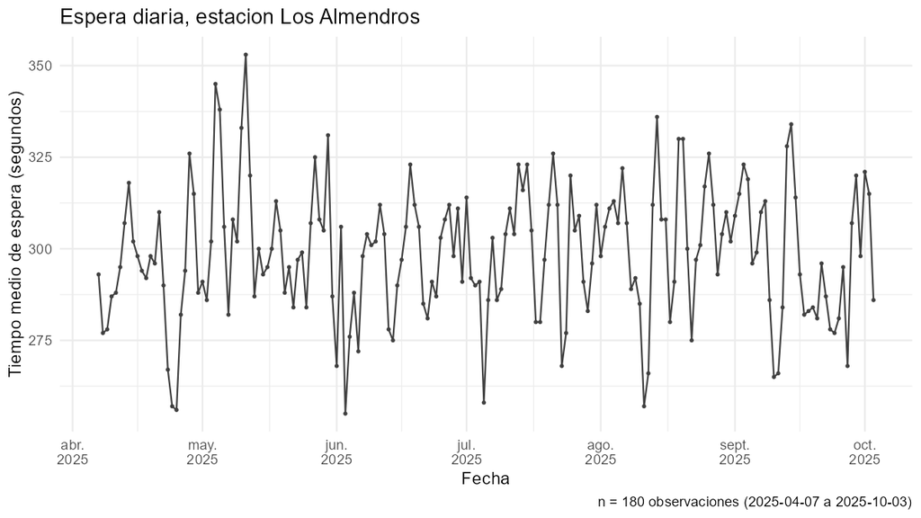

Tiempo medio diario de espera en la estación Los Almendros.

**Lectura del gráfico.** La serie oscila alrededor de un nivel de $\bar{y} = 298,8$ segundos, con desviación estándar $s = 18,0$ s, y no muestra tendencia: no sube ni baja de forma sostenida durante los $n=180$ días. La variabilidad parece estable en todo el periodo, con un mínimo de 255,0 s y un máximo de 353,0 s, este último el 2025-05-11. No se ve un patrón que se repita con regularidad; sí aparecen descensos marcados cerca del cambio de mes (por ejemplo, hacia el 1 de mayo y el 1 de junio).

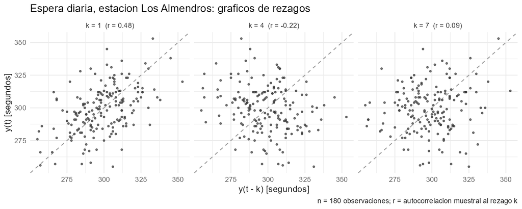

Gráficos de rezagos, serie 1.

**Rezagos elegidos y por qué.** Se eligieron $k=1$, $k=4$ y $k=7$, comparando $y_t$ con $y_{t-k}$ frente a la banda de ruido blanco $\pm 1{,}96/\sqrt{n} = \pm 0{,}146$ ($n=180$).

- **$k=1$ (día anterior).** Es el de mayor autocorrelación: $r_1 = 0{,}48$, fuera de la banda. La nube se alarga sobre la diagonal, es decir, hay dependencia positiva de corto plazo.
- **$k=4$ (el más negativo).** $r_4 = -0{,}22$, fuera de la banda por poco. La nube es casi redonda con leve inclinación descendente: la relación es débil.
- **$k=7$ (una semana).** Es el período natural de una serie diaria, pero $r_7 = 0{,}09$ cae dentro de la banda y la nube no tiene forma: no hay evidencia de dependencia semanal.

**Serie 2: pasajeros del aeropuerto**

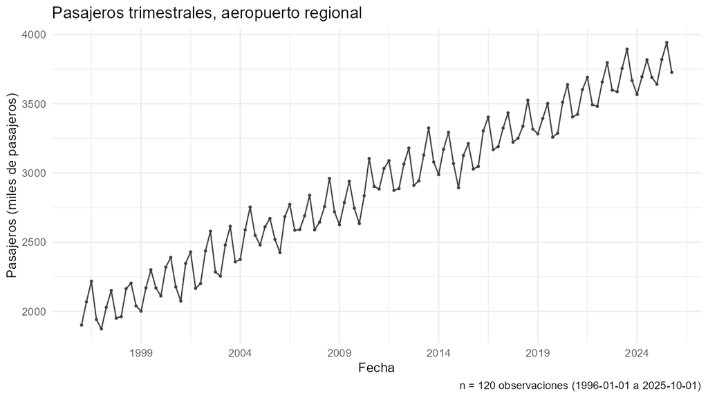

Pasajeros trimestrales del aeropuerto regional.

**Lectura del gráfico.** La serie tiene una tendencia creciente: la media anual pasa de 2032 miles de pasajeros en 1996 a 3783 en 2025, un aumento medio de 60 miles por año. Además se observa un zigzag que se repite cada año, con un trimestre alto y otro bajo, lo que sugiere estacionalidad de período $s=4$ (se decidirá en 3(b)).

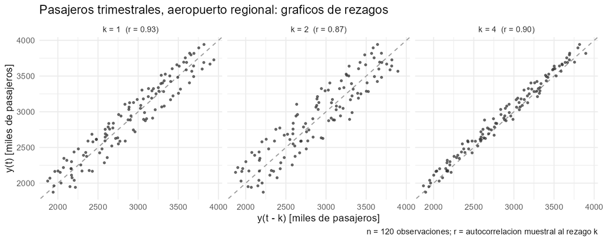

Gráficos de rezagos, serie 2.

**Rezagos elegidos y por qué.** Se eligieron $k=1$, $k=2$ y $k=4$, frente a la banda $\pm 1{,}96/\sqrt{n}=\pm 0{,}179$ ($n=120$).

- **$k=1$ (trimestre anterior).** $r_1=0{,}93$, fuera de la banda; la nube sigue la diagonal con dispersión moderada.
- **$k=2$ (fase opuesta del ciclo anual).** $r_2=0{,}87$, el más bajo de los tres; la nube es la más abierta.
- **$k=4$ (mismo trimestre del año anterior).** $r_4=0{,}90$, mayor que $r_2$ pese a estar más lejos; la nube es la más angosta y pegada a la diagonal.

Las tres autocorrelaciones son altas porque la serie tiene tendencia. Que $r_4 > r_2$ es una señal de estacionalidad anual.

**Serie 3: viajes de la plataforma**

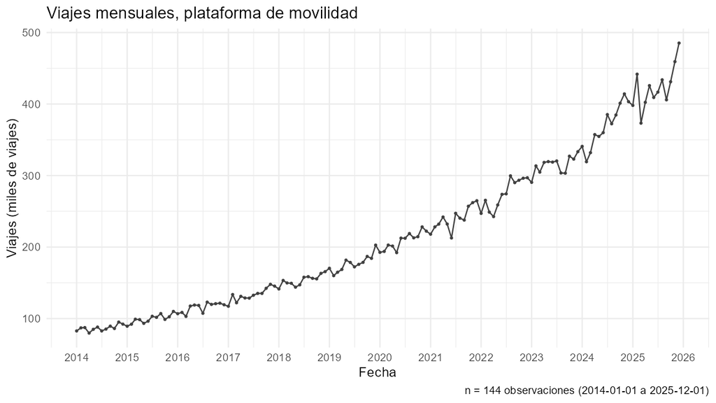

Viajes mensuales de la plataforma de movilidad.

**Lectura del gráfico.** La serie tiene una tendencia creciente: pasa de cerca de 90 mil viajes en 2014 a cerca de 490 mil en diciembre de 2025. La tendencia es curva, es decir, no es una recta: el crecimiento se acelera con el tiempo. La variabilidad mes a mes no es constante: al inicio los cambios son pequeños y al final son mucho más grandes, lo que indica que la variabilidad crece con el nivel de la serie. No se aprecia estacionalidad claramente en el gráfico.

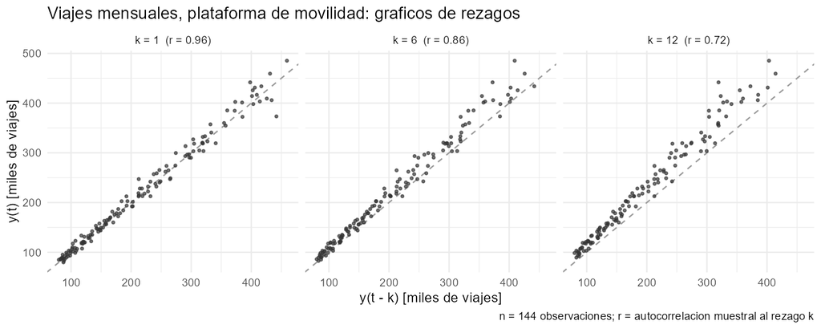

Gráficos de rezagos, serie 3.

**Rezagos elegidos y por qué.** Se escogieron los rezagos 1, 6 y 12 (mes anterior, medio año y un año), frente a la banda $\pm 1{,}96/\sqrt{n}=\pm 0{,}163$ ($n=144$). Las autocorrelaciones son positivas y altas ($r_1=0{,}96$, $r_6=0{,}86$, $r_{12}=0{,}72$), y las nubes siguen la diagonal. En $k=12$ la nube queda por encima de la diagonal, porque los valores actuales son mayores que los de hace un año. Las autocorrelaciones disminuyen lentamente a medida que crece $k$, lo que confirma la presencia de tendencia.

**Código**

```r
dplyr::bind_rows(purrr::imap(res$res3a, function(z, id) {
  data.frame(Serie = id, Rezago = z$rezagos, r = z$acf[z$rezagos],
             Banda = 1.96 / sqrt(nrow(res$datos_series[[id]])))
})) |>
  knitr::kable(digits = 3, format.args = list(decimal.mark = ","),
               col.names = c("Serie", "Rezago k", "r(k)", "Banda ±1,96/√n"))
```

Tabla 3: Autocorrelación muestral en los rezagos elegidos y banda de ruido blanco.

| Serie | Rezago k | r(k) | Banda ±1,96/√n |
| --- | --- | --- | --- |
| serie1 | 1 | 0,484 | 0,146 |
| serie1 | 4 | -0,224 | 0,146 |
| serie1 | 7 | 0,091 | 0,146 |
| serie2 | 1 | 0,934 | 0,179 |
| serie2 | 2 | 0,872 | 0,179 |
| serie2 | 4 | 0,900 | 0,179 |
| serie3 | 1 | 0,965 | 0,163 |
| serie3 | 6 | 0,856 | 0,163 |
| serie3 | 12 | 0,722 | 0,163 |

## 3.2 Estacionalidad y descomposición clásica

**Código**

```r
res$resumen3b |>
  transmute(Serie = serie, s = s, Versión = version, F = F, `g.l.` = paste0(gl1, ", ", gl2),
            `Valor p` = p, `R² estacional` = R2_estacional,
            `Rango índices (%)` = rango_indices_pct, `r(s)` = r_s, Banda = banda_rb,
            `r(amplitud, nivel)` = cor_amplitud_nivel) |>
  knitr::kable(digits = 3, format.args = list(decimal.mark = ","))
```

Tabla 4: Evidencia de estacionalidad de cada serie.

| Serie | s | Versión | F | g.l. | Valor p | R² estacional | Rango índices (%) | r(s) | Banda | r(amplitud, nivel) |
| --- | --- | --- | --- | --- | --- | --- | --- | --- | --- | --- |
| serie1 | 7 | aditiva | 2,316 | 6, 167 | 0,036 | 0,077 | 4,068 | 0,091 | 0,146 | 0,072 |
| serie2 | 4 | aditiva | 531,616 | 3, 112 | 0,000 | 0,934 | 9,523 | 0,900 | 0,179 | -0,082 |
| serie3 | 12 | multiplicativa | 1,428 | 11, 120 | 0,169 | 0,116 | 3,971 | 0,722 | 0,163 | 0,933 |

**Serie 1: espera en estación**

**Código**

```r
bloque_3b("serie1")
```

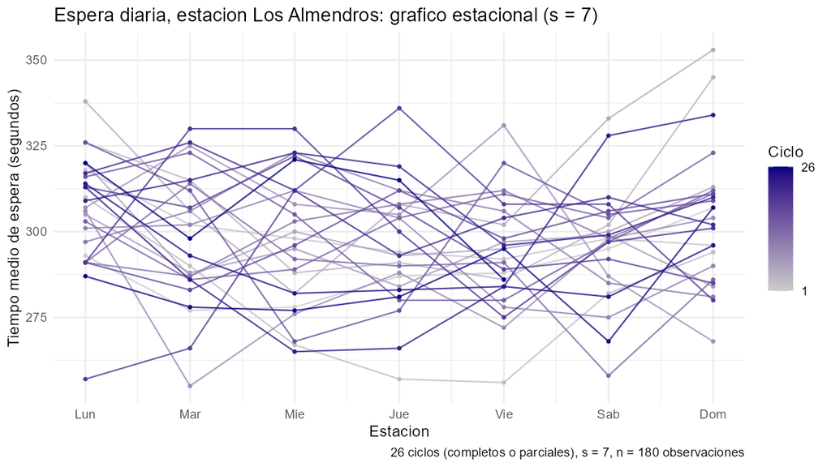

Gráfico estacional: un trazo por ciclo sobre el índice de estación.

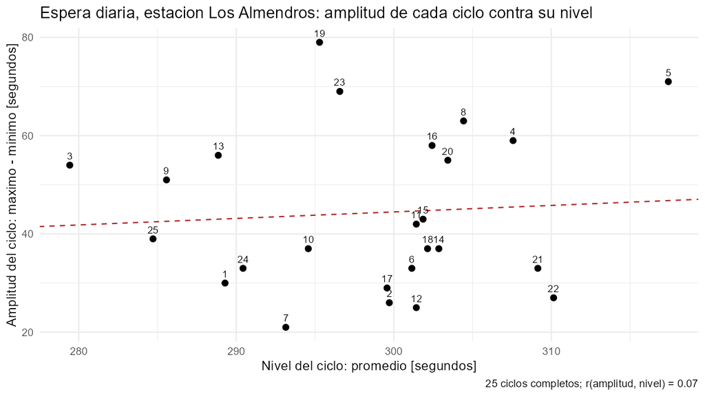

Amplitud de cada ciclo contra su nivel.

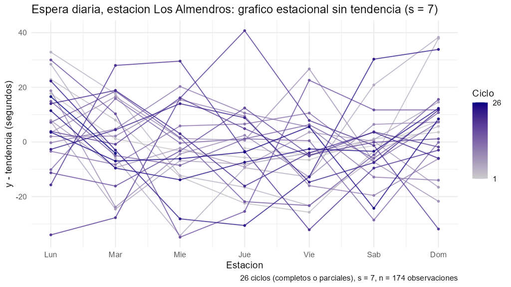

Gráfico estacional de la serie sin tendencia.

**Prueba F de estacionalidad (sobre la serie sin tendencia).**

| Elemento | Contenido |
| --- | --- |
| 1. Hipotesis | H0: mu_1 = … = mu_7 (la serie sin tendencia tiene la misma media en las 7 estaciones); H1: al menos una media estacional es distinta |
| 2. Estadistico y distribucion | F = [SCE/(s-1)] / [SCD/(n-s)] ~ F con 6 y 167 g.l. bajo H0 |
| 3. Region de rechazo (5 %) | F > 2.153 |
| 4. Observado y valor p | observado = 2.3158; valor p = 0.03568 |
| 5. Decision | Se rechaza H0 al 5 % |
| 6. Lectura | Las medias por estacion de Espera diaria, estacion Los Almendros difieren de forma significativa: hay efecto estacional de periodo 7. |

**Decisión sobre la estacionalidad.** La serie 1 no presenta estacionalidad semanal relevante ($s=7$): en el gráfico estacional las semanas no siguen una forma común, y aunque la prueba F rechaza $H_0$ ($F=2,32$, $p=0,036$), es decir, al menos una media por día de la semana es distinta, el efecto es pequeño: los días explican solo el 7,7 % de la variación ($R^2=0,077$), el rango de los índices es el 4,1 % del nivel medio y $r_7=0,09$ queda dentro de la banda de ruido blanco $\pm 0,146$. Que una diferencia sea estadísticamente significativa no implica que sea importante, por eso no se atribuye estacionalidad semanal.

**Serie 2: pasajeros del aeropuerto**

**Código**

```r
bloque_3b("serie2")
```

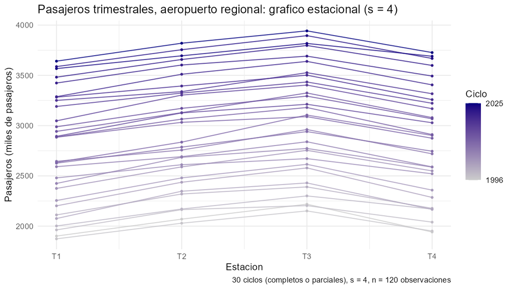

Gráfico estacional: un trazo por ciclo sobre el índice de estación.

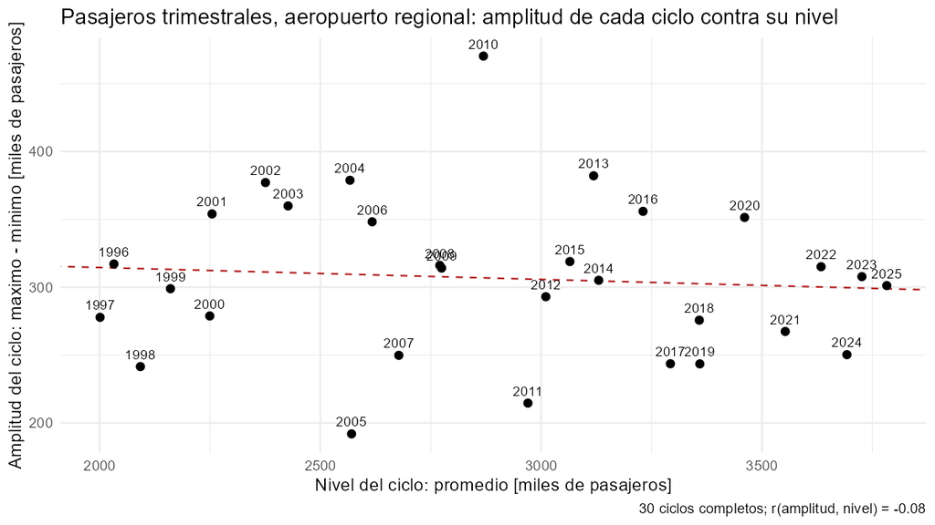

Amplitud de cada ciclo contra su nivel.

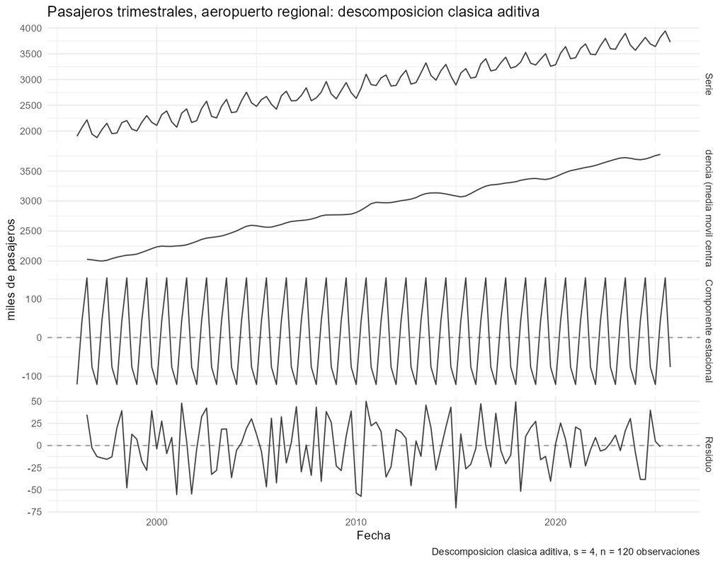

Descomposición clásica: serie, tendencia, componente estacional y residuo.

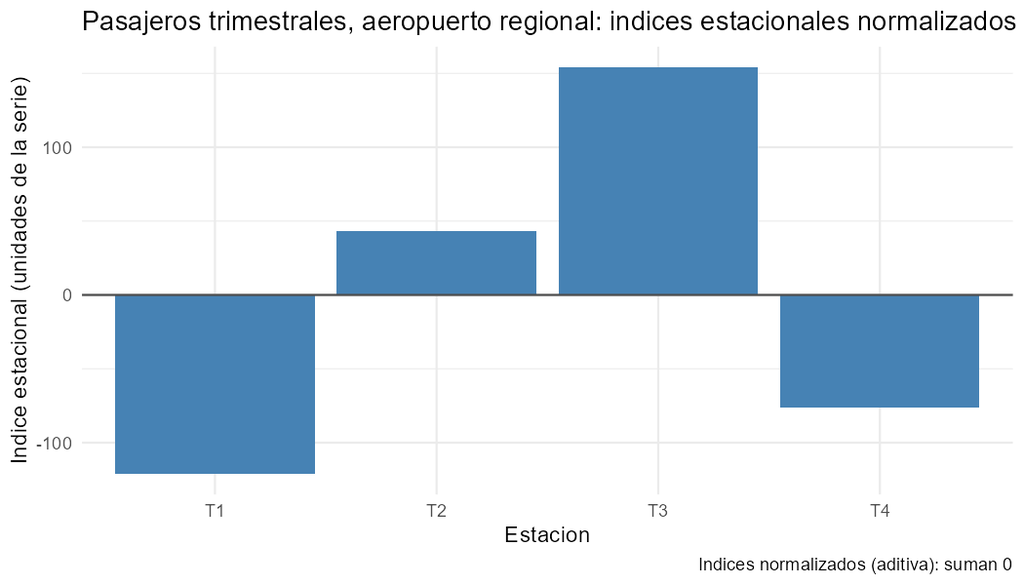

Índices estacionales normalizados.

**Prueba F de estacionalidad (sobre la serie sin tendencia).**

| Elemento | Contenido |
| --- | --- |
| 1. Hipotesis | H0: mu_1 = … = mu_4 (la serie sin tendencia tiene la misma media en las 4 estaciones); H1: al menos una media estacional es distinta |
| 2. Estadistico y distribucion | F = [SCE/(s-1)] / [SCD/(n-s)] ~ F con 3 y 112 g.l. bajo H0 |
| 3. Region de rechazo (5 %) | F > 2.686 |
| 4. Observado y valor p | observado = 531.6161; valor p = < 2.2e-16 |
| 5. Decision | Se rechaza H0 al 5 % |
| 6. Lectura | Las medias por estacion de Pasajeros trimestrales, aeropuerto regional difieren de forma significativa: hay efecto estacional de periodo 4. |

**Serie 3: viajes de la plataforma**

**Código**

```r
bloque_3b("serie3")
```

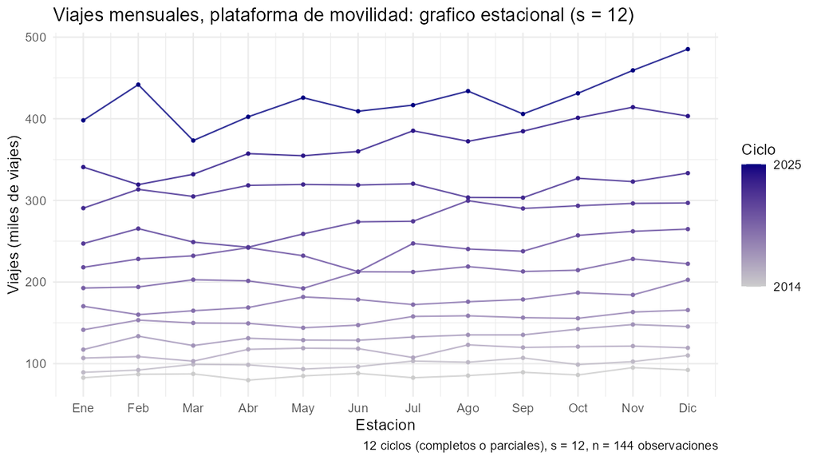

Gráfico estacional: un trazo por ciclo sobre el índice de estación.

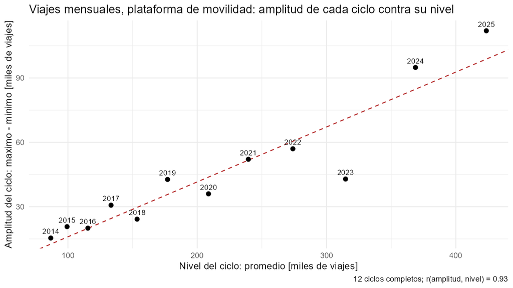

Amplitud de cada ciclo contra su nivel.

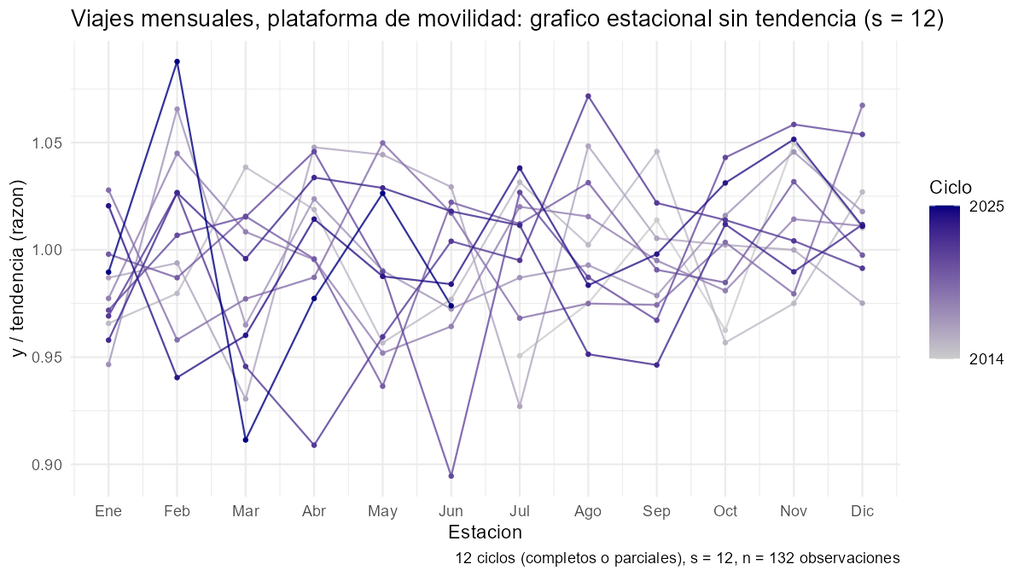

Gráfico estacional de la serie sin tendencia.

**Prueba F de estacionalidad (sobre la serie sin tendencia).**

| Elemento | Contenido |
| --- | --- |
| 1. Hipotesis | H0: mu_1 = … = mu_12 (la serie sin tendencia tiene la misma media en las 12 estaciones); H1: al menos una media estacional es distinta |
| 2. Estadistico y distribucion | F = [SCE/(s-1)] / [SCD/(n-s)] ~ F con 11 y 120 g.l. bajo H0 |
| 3. Region de rechazo (5 %) | F > 1.869 |
| 4. Observado y valor p | observado = 1.4280; valor p = 0.169 |
| 5. Decision | No se rechaza H0 al 5 % |
| 6. Lectura | No hay evidencia de que las medias por estacion de Viajes mensuales, plataforma de movilidad difieran. |

## 3.3 Correlograma de la serie sin transformar y clasificación del patrón

Se calcula el correlograma de cada serie *sin transformar* con $m=\min\{\lfloor T/4\rfloor,\,24\}$ rezagos, con la banda de ruido blanco ($\pm 1{,}96/\sqrt{n}$, recta) y la banda secuencial de Bartlett (curva).

**Código**

```r
res$resumen3c |>
  transmute(Serie = serie, T = T, m = m, `Banda ±1,96/√n` = banda_rb,
            `r(1)` = r1, `r(s)` = r_s,
            `Fuera de la banda RB` = rezagos_fuera_rb,
            `Fuera de la banda Bartlett` = rezagos_fuera_bartlett,
            `Primer rezago dentro de RB` = primer_rezago_dentro,
            `Rezagos con r > 0` = positivos) |>
  knitr::kable(digits = 3, format.args = list(decimal.mark = ","))
```

Tabla 5: Lectura numérica del correlograma de la serie sin transformar.

| Serie | T | m | Banda ±1,96/√n | r(1) | r(s) | Fuera de la banda RB | Fuera de la banda Bartlett | Primer rezago dentro de RB | Rezagos con r > 0 |
| --- | --- | --- | --- | --- | --- | --- | --- | --- | --- |
| serie1 | 180 | 24 | 0,146 | 0,484 | 0,091 | 1, 4, 6, 17 | 1, 4 | 2 | 10 |
| serie2 | 120 | 24 | 0,179 | 0,934 | 0,900 | 1-24 | 1-11 | NA | 24 |
| serie3 | 144 | 24 | 0,163 | 0,965 | 0,722 | 1-24 | 1-13 | NA | 24 |

**Serie 1: espera en estación**

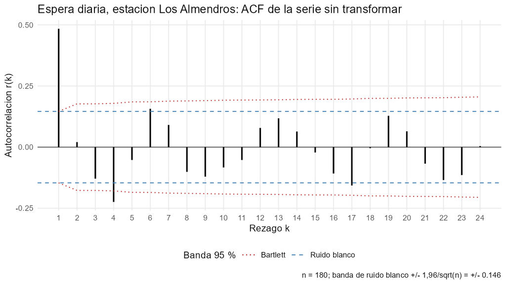

ACF de la serie 1 sin transformar.

**Clasificación del patrón.** La serie es de tipo I: nivel estable, sin tendencia ni estacionalidad, con dependencia solo de corto plazo.

**Serie 2: pasajeros del aeropuerto**

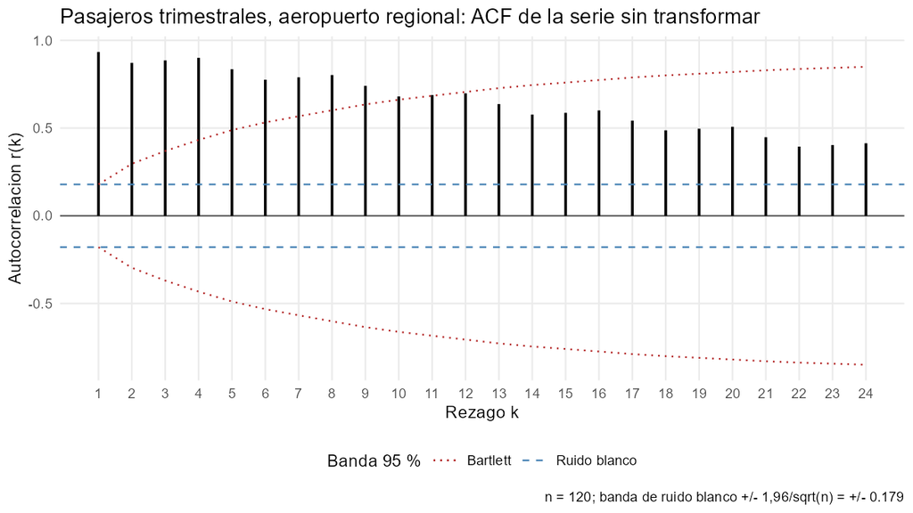

ACF de la serie 2 sin transformar.

**Clasificación del patrón.** La serie es de tipo IV: con tendencia y estacionalidad.

**Serie 3: viajes de la plataforma**

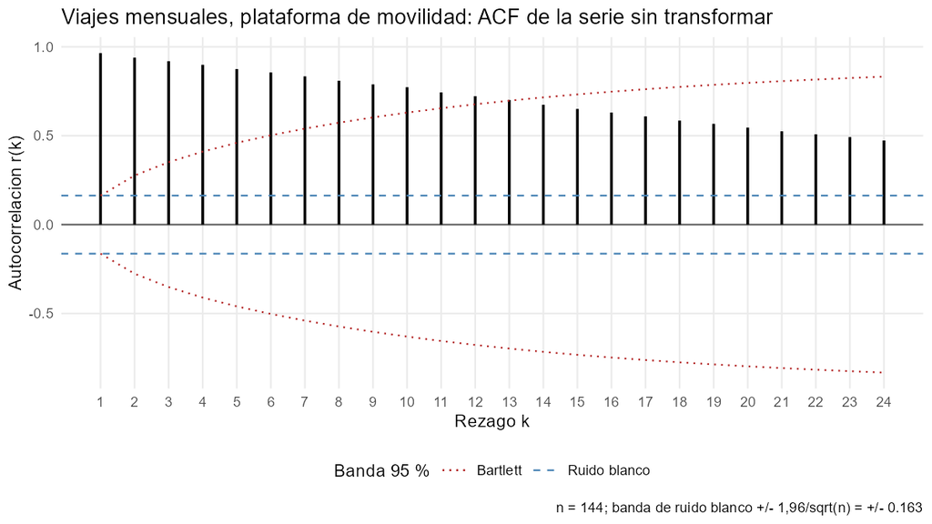

ACF de la serie 3 sin transformar.

**Clasificación del patrón.** La serie es de tipo III: con tendencia y sin estacionalidad.

# 4 Operador de rezago

## 4.1 Funciones y verificación

`diferenciar(y, d, D, s)` aplica $(1-B)^d(1-B^s)^D$ restando valores desplazados, sin usar `diff()`, y `polinomio_rezago(coef)` devuelve las raíces de $c(B)=1+c_1B+\cdots+c_pB^p$ con su módulo, usando `polyroot()`.

| Comparacion | Maxima diferencia con diff() |
| --- | --- |
| (1-B) | 0e+00 |
| (1-B)^2 | 0e+00 |
| (1-B^12) | 0e+00 |
| (1-B)(1-B^12) | 0e+00 |

Las diferencias son cero (o del orden de $10^{-15}$), de modo que `diferenciar()` reproduce a `diff()`. Para `polinomio_rezago()`, el polinomio $1-B^{12}$ tiene 12 raíces, todas con módulo 1 (error máximo 1.5e-14), y el polinomio $1-0{,}6B$ tiene la raíz $1/0{,}6$, como debe ser.

## 4.2 Transformaciones candidatas, polinomios y raíces

Se usan dos propiedades del operador de rezago. El factor $(1-B)^d$ anula cualquier polinomio de grado menor que $d$ y deja constante una tendencia de grado $d$. El factor $(1-B^s)$ anula cualquier patrón determinista de período $s$, porque $S_t-S_{t-s}=0$; sus raíces son las $s$ raíces de la unidad, $e^{2\pi i k/s}$, de período $s/k$. Todas las raíces de estos factores están sobre el círculo unidad (módulo 1), lo cual es lo que se espera de un operador de diferencia.

**Serie 1: espera en estación**

El diagnóstico de la sección 3 (nivel estable, sin tendencia ni estacionalidad) no exige transformar. La candidata principal es la serie sin transformar, con $c(B)=1$, que no tiene raíces. Como contraste se incluye $(1-B)$, para comprobar más adelante que diferenciar una serie que ya era estacionaria es innecesario.

| Escala previa | Operador | Polinomio $c(B)$ | Grado |
| --- | --- | --- | --- |
| ninguna | $1$ | $1$ | 0 |
| ninguna | $(1-B)$ | $1 - B$ | 1 |

| Operador | Re | Im | Modulo | Periodo |
| --- | --- | --- | --- | --- |
| $(1-B)$ | 1 | 0 | 1 | $\infty$ |

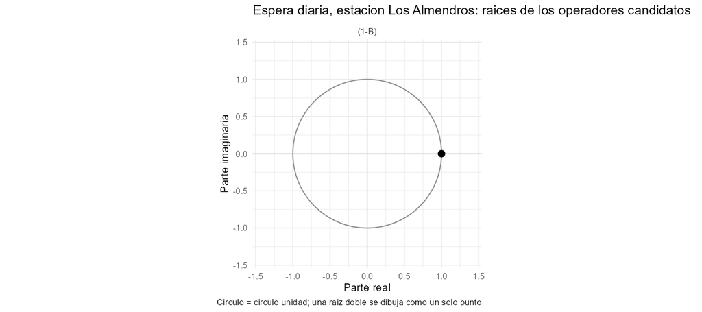

Raíces de los operadores candidatos, serie 1.

**Lectura.** La raíz $B=1$ de $(1-B)$ (módulo 1, período $\infty$) corresponde a un nivel constante: el factor anula la media y, ante una tendencia lineal, la dejaría constante. Como esta serie no tiene tendencia, ese factor solo agregaría una raíz unitaria innecesaria.

**Serie 2: pasajeros del aeropuerto**

La serie tiene tendencia y estacionalidad de período $s=4$. Las candidatas son $(1-B)$ para la tendencia, $(1-B^{4})$ para la estacionalidad y el producto $(1-B)(1-B^{4})$ para ambas.

| Escala previa | Operador | Polinomio $c(B)$ | Grado |
| --- | --- | --- | --- |
| ninguna | $1$ | $1$ | 0 |
| ninguna | $(1-B)$ | $1 - B$ | 1 |
| ninguna | $(1-B^{4})$ | $1 - B^{4}$ | 4 |
| ninguna | $(1-B)(1-B^{4})$ | $1 - B - B^{4} + B^{5}$ | 5 |

| Operador | Re | Im | Modulo | Periodo |
| --- | --- | --- | --- | --- |
| $(1-B)$ | 1 | 0 | 1 | $\infty$ |
| $(1-B^{4})$ | 0 | -1 | 1 | 4 |
| $(1-B^{4})$ | 1 | 0 | 1 | $\infty$ |
| $(1-B^{4})$ | 0 | 1 | 1 | 4 |
| $(1-B^{4})$ | -1 | 0 | 1 | 2 |
| $(1-B)(1-B^{4})$ | 0 | -1 | 1 | 4 |
| $(1-B)(1-B^{4})$ | 1 | 0 | 1 | $\infty$ |
| $(1-B)(1-B^{4})$ | 1 | 0 | 1 | $\infty$ |
| $(1-B)(1-B^{4})$ | 0 | 1 | 1 | 4 |
| $(1-B)(1-B^{4})$ | -1 | 0 | 1 | 2 |

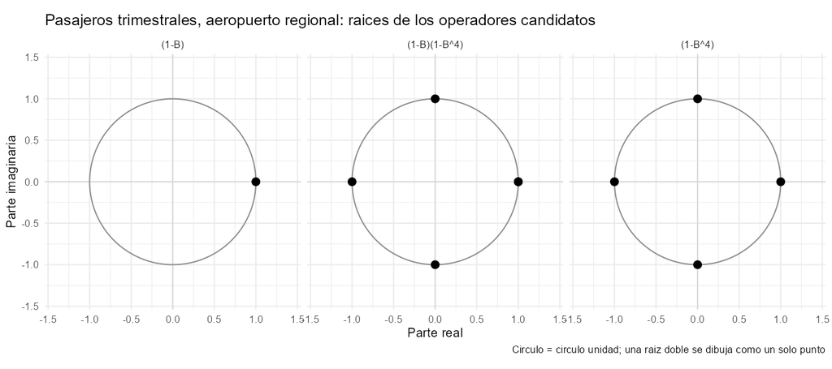

Raíces de los operadores candidatos, serie 2.

**Lectura.** Las raíces de $(1-B)$ y $(1-B^{4})$ son:

- $B=1$ (período $\infty$): elimina el nivel constante y, ante una tendencia lineal, la deja constante.
- $B=\pm i$ (período 4): elimina el ciclo anual de cuatro trimestres.
- $B=-1$ (período 2): elimina el ciclo semestral.

El producto $(1-B)(1-B^{4})=1-B-B^{4}+B^{5}$ tiene la raíz $B=1$ doble, porque el factor $(1-B)$ aparece dos veces; por eso elimina una tendencia lineal además del patrón estacional.

**Serie 3: viajes de la plataforma**

La serie tiene tendencia curva, sin estacionalidad, y una variabilidad que crece con el nivel (los cambios de un mes a otro son pequeños al inicio y grandes al final). La transformación previa de escala es $\log Y_t$, que no es un polinomio en $B$: estabiliza la variabilidad y vuelve aproximadamente lineal una tendencia que crece a tasa constante. Sobre $Y_t$ y sobre $\log Y_t$ se evalúan $(1-B)$ y $(1-B)^2$; los polinomios y las raíces son los mismos en las dos escalas.

| Escala previa | Operador | Polinomio $c(B)$ | Grado |
| --- | --- | --- | --- |
| ninguna | $1$ | $1$ | 0 |
| ninguna | $(1-B)$ | $1 - B$ | 1 |
| ninguna | $(1-B)^{2}$ | $1 - 2B + B^{2}$ | 2 |
| $\log Y_t$ | $1$ | $1$ | 0 |
| $\log Y_t$ | $(1-B)$ | $1 - B$ | 1 |
| $\log Y_t$ | $(1-B)^{2}$ | $1 - 2B + B^{2}$ | 2 |

| Operador | Re | Im | Modulo | Periodo |
| --- | --- | --- | --- | --- |
| $(1-B)$ | 1 | 0 | 1 | $\infty$ |
| $(1-B)^{2}$ | 1 | 0 | 1 | $\infty$ |
| $(1-B)^{2}$ | 1 | 0 | 1 | $\infty$ |
| $\log$, $(1-B)$ | 1 | 0 | 1 | $\infty$ |
| $\log$, $(1-B)^{2}$ | 1 | 0 | 1 | $\infty$ |
| $\log$, $(1-B)^{2}$ | 1 | 0 | 1 | $\infty$ |

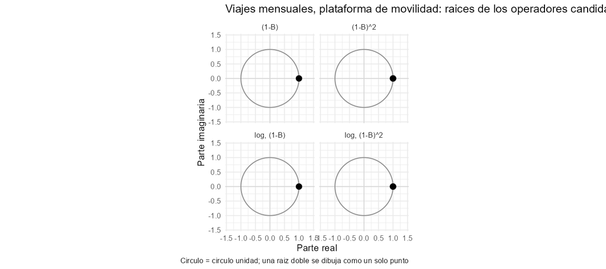

Raíces de los operadores candidatos, serie 3.

**Lectura.** $(1-B)$ tiene la raíz $B=1$ y elimina una tendencia constante. $(1-B)^2=1-2B+B^{2}$ tiene la raíz $B=1$ doble y elimina una tendencia lineal, dejando constante una cuadrática. La serie 3 no lleva factor estacional porque no se le atribuyó estacionalidad en 3(b), así que ninguna candidata incluye $(1-B^{12})$.

## 4.3 Elección de la transformación y defensa de que no se diferencia de más

Para cada serie se compara la serie original con cada candidata de 4.2 mediante la varianza muestral y la autocorrelación de primer orden $r_1$. La razón de varianzas se calcula dentro de la misma escala, porque la varianza de $\log Y_t$ no es comparable con la de $Y_t$.

**Criterio.** Para un proceso estacionario con autocorrelación $\rho_1$,

$$\operatorname{Var}(\nabla Y_t)=\operatorname{Var}(Y_t)+\operatorname{Var}(Y_{t-1})-2\operatorname{Cov}(Y_t,Y_{t-1})=2\gamma(0)-2\gamma(1)=2\gamma(0)(1-\rho_1).$$

Si la serie ya era estacionaria, diferenciar multiplica la varianza por $2(1-\rho_1)$, que es 2 cuando $\rho_1=0$, y empuja $r_1$ hacia $-0{,}5$ (para ruido blanco, $\rho_1(\nabla Y)=-1/2$). En cambio, si la serie tiene tendencia o raíz unitaria, diferenciar reduce la varianza de forma drástica. Por eso se elige la candidata que más reduce la varianza sin que un factor adicional la vuelva a subir: todo factor que suba la varianza y empuje $r_1$ hacia $-0{,}5$ o más allá es una diferencia de más. Un $r_1$ negativo tras diferenciar es una alerta que se discute caso por caso, porque una tendencia determinista más ruido blanco también deja $\rho_1=-1/2$ al diferenciarla: si $Y_t=\beta_0+\beta_1t+\varepsilon_t$, entonces $\nabla Y_t=\beta_1+\varepsilon_t-\varepsilon_{t-1}$. La identidad vale con las estimaciones muestrales solo si la serie es estacionaria.

**Código**

```r
etiqueta_cand <- function(x) ifelse(x == "1", "sin diferenciar",
                             ifelse(x == "log, 1", "log, sin diferenciar", x))

tabla_4c_serie <- function(id) {
  res$tabla_4c |> filter(serie == id) |>
    transmute(Candidata = etiqueta_cand(candidata), n, Media = media,
              `Media esperada` = media_esperada, Varianza = varianza,
              `Var / Var sin dif.` = razon_var, `r(1)` = r1) |>
    knitr::kable(digits = 4, format.args = list(decimal.mark = ",", big.mark = "."))
}

identidad_4c_serie <- function(id) {
  res$identidad_4c |> filter(serie == id) |>
    transmute(Escala = escala, `γ(0)` = gamma0, `γ(1)` = gamma1, `Var(∇Y)` = lado_izq,
              `2γ(0) − 2γ(1)` = lado_der, `Diferencia relativa` = dif_relativa) |>
    knitr::kable(digits = 4, format.args = list(decimal.mark = ",", big.mark = "."))
}

media_4c_serie <- function(id) {
  e <- res$elegida_4c[[id]]
  op <- res$tabla_4c |> filter(serie == id, escala == e$escala, d == e$d, D == e$D) |> pull(candidata)
  res$media_elegida |> filter(serie == id) |>
    transmute(Operador = etiqueta_cand(op), n, Media = media, `Media esperada` = media_esperada,
              `Error estándar ingenuo` = sqrt(varianza / n),
              `Diferencia / error` = (media - media_esperada) / sqrt(varianza / n)) |>
    knitr::kable(digits = 4, format.args = list(decimal.mark = ","))
}
```

**Serie 1: espera en estación**

**Código**

```r
tabla_4c_serie("serie1")
```

Tabla 6: Serie 1: varianza muestral y r(1) de la serie y de sus candidatas.

| Candidata | n | Media | Media esperada | Varianza | Var / Var sin dif. | r(1) |
| --- | --- | --- | --- | --- | --- | --- |
| sin diferenciar | 180 | 298,7667 | 298,7667 | 323,5877 | 1,0000 | 0,4840 |
| (1-B) | 179 | -0,0391 | 0,0150 | 334,7119 | 1,0344 | -0,0465 |

**Código**

```r
identidad_4c_serie("serie1")
```

Tabla 7: Serie 1: identidad Var(∇Y) = 2γ(0) − 2γ(1).

| Escala | γ(0) | γ(1) | Var(∇Y) | 2γ(0) − 2γ(1) | Diferencia relativa |
| --- | --- | --- | --- | --- | --- |
| ninguna | 321,79 | 155,7477 | 332,842 | 332,0847 | 0,0023 |

**Código**

```r
media_4c_serie("serie1")
```

Tabla 8: Serie 1: media de la serie elegida frente a la que debe dejar el operador.

| Operador | n | Media | Media esperada | Error estándar ingenuo | Diferencia / error |
| --- | --- | --- | --- | --- | --- |
| sin diferenciar | 180 | 298,7667 | 298,7667 | 1,3408 | 0 |

**Elección: ninguna transformación.** Diferenciar no reduce la varianza, la sube un 3,4 % (de 323,6 a 334,7 s²), y eso es lo que predice la identidad: $2(1-r_1)=2(1-0{,}484)=1{,}03$. La identidad, calculada con el divisor $n$ de la ACF, da 332,8 contra 332,1, una diferencia de apenas 0,2 % (la varianza de 334,7 de la tabla usa el divisor $n-1$); se cumple, lo cual es compatible con una serie estacionaria. La pendiente de la recta ajustada es 0,015 s por día, unos 2,7 s en todo el período frente a una desviación estándar de 18 s, así que no hay tendencia. Además, diferenciar introduce autocorrelación artificial: la serie diferenciada tiene $r_2=-0{,}30$ y $r_4=-0{,}25$, fuera de la banda $\pm$ 0,146. Como no se diferencia, la media de la serie es su nivel: 298,8 s, por debajo de la meta contractual de 330 s.

**Serie 2: pasajeros del aeropuerto**

**Código**

```r
tabla_4c_serie("serie2")
```

Tabla 9: Serie 2: varianza muestral y r(1) de la serie y de sus candidatas.

| Candidata | n | Media | Media esperada | Varianza | Var / Var sin dif. | r(1) |
| --- | --- | --- | --- | --- | --- | --- |
| sin diferenciar | 120 | 2.894,1975 | 2.894,1975 | 305.556,570 | 1,0000 | 0,9338 |
| (1-B) | 119 | 15,3437 | 15,5188 | 26.325,883 | 0,0862 | -0,0626 |
| (1-B^4) | 116 | 60,3526 | 62,0754 | 5.065,193 | 0,0166 | 0,5835 |
| (1-B)(1-B^4) | 115 | 0,5617 | 0,0000 | 4.183,183 | 0,0137 | -0,0572 |

**Código**

```r
identidad_4c_serie("serie2")
```

Tabla 10: Serie 2: identidad Var(∇Y) = 2γ(0) − 2γ(1).

| Escala | γ(0) | γ(1) | Var(∇Y) | 2γ(0) − 2γ(1) | Diferencia relativa |
| --- | --- | --- | --- | --- | --- |
| ninguna | 303.010,3 | 282.950,8 | 26.104,66 | 40.118,94 | 0,5368 |

**Código**

```r
media_4c_serie("serie2")
```

Tabla 11: Serie 2: media de la serie elegida frente a la que debe dejar el operador.

| Operador | n | Media | Media esperada | Error estándar ingenuo | Diferencia / error |
| --- | --- | --- | --- | --- | --- |
| (1-B)(1-B^4) | 115 | 0,5617 | 0 | 6,0312 | 0,0931 |

**Elección: $(1-B)(1-B^4)$.** La varianza cae de 305.557 a 26.326 con $(1-B)$, a 5.065 con $(1-B^4)$ y a 4.183 con $(1-B)(1-B^4)$, la mínima de las cuatro. Con el producto, $r_1=-0{,}057$, lejos de $-0{,}5$, así que no hay señal de sobrediferenciación. La diferencia estacional sola no basta: deja $r_1=0{,}58$ y media 60,4, casi cuatro veces la pendiente de la tendencia ($4\times 15{,}5=62{,}1$), es decir, todavía queda tendencia lineal, y por eso hace falta el factor $(1-B)$. La media final es 0,56 en miles de pasajeros (unos 560 pasajeros), a 0,09 errores estándar del 0 que debe dejar el operador. La identidad falla (54 % de diferencia), como corresponde a una serie con tendencia, que no es estacionaria.

**Serie 3: viajes de la plataforma**

**Código**

```r
tabla_4c_serie("serie3")
```

Tabla 12: Serie 3: varianza muestral y r(1) de la serie y de sus candidatas.

| Candidata | n | Media | Media esperada | Varianza | Var / Var sin dif. | r(1) |
| --- | --- | --- | --- | --- | --- | --- |
| sin diferenciar | 144 | 216,2118 | 216,2118 | 11.389,7255 | 1,0000 | 0,9647 |
| (1-B) | 143 | 2,8154 | 2,4863 | 166,6951 | 0,0146 | -0,3898 |
| (1-B)^2 | 142 | 0,1528 | 0,0000 | 462,7846 | 0,0406 | -0,6004 |
| log, sin diferenciar | 144 | 5,2528 | 5,2528 | 0,2546 | 1,0000 | 0,9729 |
| log, (1-B) | 143 | 0,0124 | 0,0121 | 0,0027 | 0,0106 | -0,4218 |
| log, (1-B)^2 | 142 | 0,0000 | 0,0000 | 0,0077 | 0,0301 | -0,5992 |

**Código**

```r
identidad_4c_serie("serie3")
```

Tabla 13: Serie 3: identidad Var(∇Y) = 2γ(0) − 2γ(1).

| Escala | γ(0) | γ(1) | Var(∇Y) | 2γ(0) − 2γ(1) | Diferencia relativa |
| --- | --- | --- | --- | --- | --- |
| ninguna | 11.310,6302 | 10.911,1926 | 165,5294 | 798,8753 | 3,8262 |
| log | 0,2528 | 0,2459 | 0,0027 | 0,0137 | 4,1361 |

**Código**

```r
media_4c_serie("serie3")
```

Tabla 14: Serie 3: media de la serie elegida frente a la que debe dejar el operador.

| Operador | n | Media | Media esperada | Error estándar ingenuo | Diferencia / error |
| --- | --- | --- | --- | --- | --- |
| log, (1-B) | 143 | 0,0124 | 0,0121 | 0,0043 | 0,0724 |

**Elección: $\log Y_t$ y $(1-B)$.** La escala logarítmica se justifica con la varianza de los cambios: la de $\nabla Y_t$ pasa de 40,6 en la primera mitad de la serie a 292,2 en la segunda (siete veces más), mientras que la de $\nabla\log Y_t$ se mantiene en 0,00266 y 0,00274. Con $\nabla\log Y_t$ la varianza baja de 0,255 a 0,00269 (razón 0,011). Agregar un segundo factor es una diferencia de más: con $(1-B)^2$ la varianza se multiplica por 2,9 (de 0,00269 a 0,00767) y $r_1$ baja a $-0{,}60$, todavía más negativo que con un solo factor. La media de $\nabla\log Y_t$ es 0,0124, casi igual a la pendiente de la recta ajustada al logaritmo (0,0121); equivale a un crecimiento de 1,24 % mensual, unos 16 % anual. Una cautela sobre $r_1=-0{,}42$, que con $(1-B)$ no queda lejos de $-0{,}5$. Es también lo que deja una tendencia determinista con ruido blanco, porque entonces $\nabla\log Y_t=\beta_1+\varepsilon_t-\varepsilon_{t-1}$ tiene $\rho_1=-1/2$; así, parte de la tendencia podría ser determinista y no estocástica. Aun así $(1-B)$ es la candidata menos mala: $\log Y_t$ sin diferenciar tiene tendencia y no es estacionaria en media, y $(1-B)^2$ empeora ($r_1=-0{,}60$ y varianza multiplicada por 2,9). Esto se revisa en la sección 5 con la ACF y la PACF de la serie transformada y en 6(b) con la regresión sobre una tendencia. La identidad falla (diferencia relativa de 4,1, es decir, 410 %), como en cualquier serie con tendencia.

**Qué le pasa a $r_1$ al diferenciar una serie estacionaria.** Con 500 valores de ruido blanco simulado, el único caso en que se conoce la respuesta, se obtiene lo que predice la teoría.

**Código**

```r
res$sobrediferencia |>
  transmute(`r(1) del ruido` = r1_ruido, `r(1) de la diferencia` = r1_difer,
            `Var(dif) / Var(ruido)` = razon_var) |>
  knitr::kable(digits = 3, format.args = list(decimal.mark = ","))
```

Tabla 15: Efecto de diferenciar un ruido blanco simulado (n = 500).

| r(1) del ruido | r(1) de la diferencia | Var(dif) / Var(ruido) |
| --- | --- | --- |
| -0,065 | -0,539 | 2,127 |

**Transformaciones elegidas.** El error estándar de las tablas de media es el ingenuo, a modo de verificación preliminar; el adecuado, con la varianza de largo plazo, se construye en 5(c).

| Serie | Transformación | Escrita en $B$ | Plausiblemente estacionaria |
| --- | --- | --- | --- |
| 1 | ninguna | $1$ | sí; la identidad se cumple al 0,2 % |
| 2 | $(1-B)(1-B^4)$ | $1-B-B^4+B^5$ | sí; $r_1=-0{,}057$, media 0,56 |
| 3 | $\log$ y $(1-B)$ | $1-B$ | con la cautela de $r_1=-0{,}42$ |

## 4.4 Las funciones de pronóstico de Holt y Holt–Winters como soluciones de ecuaciones en diferencias

**Convención.** Desde el origen $T$, los pronósticos son una función del horizonte $h=1,2,\dots$: $f(h)=\hat Y_{T+h}$. Los números $L_T$, $\hat T_T$ y $S_{T-s+1},\dots,S_T$ ya están calculados en $T$ y no dependen de $h$. Aquí el operador de rezago actúa sobre $h$, no sobre el tiempo: $Bf(h)=f(h-1)$. Esa expresión solo es un pronóstico si $h-1\ge 1$, porque $f(0)=\hat Y_T$ no lo es. De ahí salen los rangos de $h$ que pide el enunciado.

**Holt**

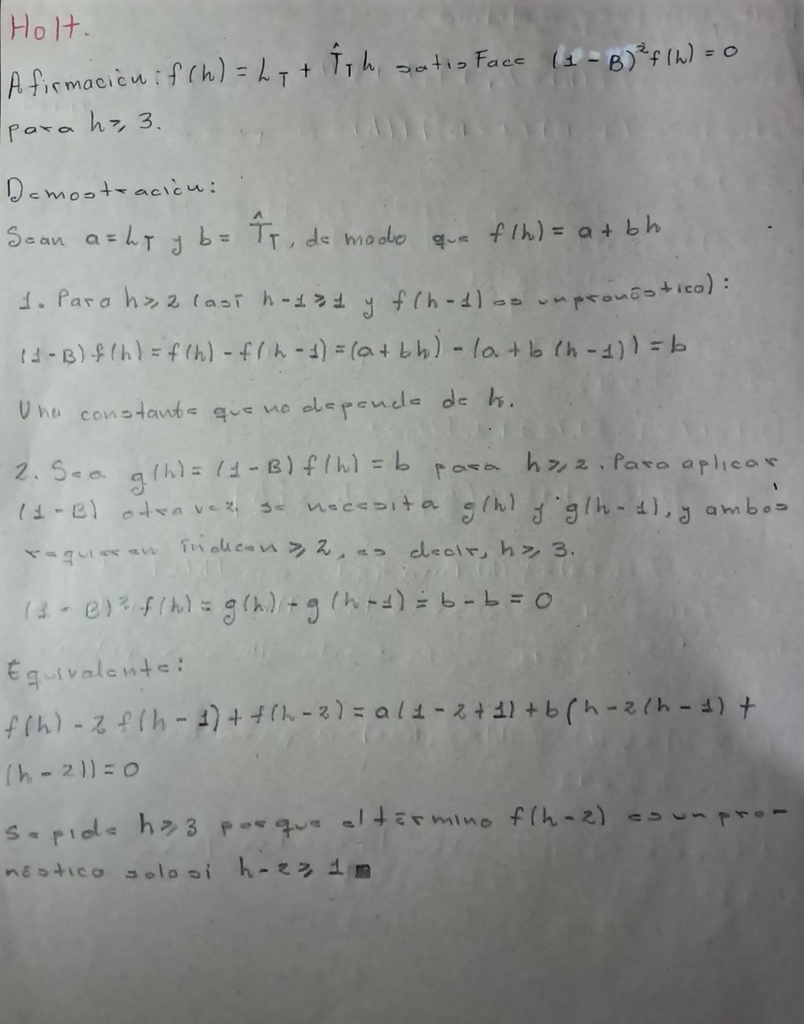

Figura 1: Demostración a mano: $f(h)=L_T+\hat T_T\,h$ satisface $(1-B)^2f(h)=0$ para $h\ge 3$.

**Solución general.** El polinomio característico es $c(z)=(1-z)^2$, con la raíz $z=1$ de multiplicidad $m=2$, así que $R=z^{-1}=1$. Con la fórmula de las clases 7 y 8, $Z_h=\sum_i\sum_{j=0}^{m_i-1}b_{ij}\,h^jR_i^h$, queda

$$f(h)=(b_0+b_1h)\cdot 1^h=b_0+b_1h .$$

Toda solución es una recta. Holt elige la recta con $b_0=L_T$ y $b_1=\hat T_T$.

**Qué raíces corresponden a qué.** La raíz $z=1$ (módulo 1, período $\infty$) es la única, y es doble. La primera copia aporta el nivel $b_0$ (una constante). La segunda copia, por ser raíz repetida, multiplica por $h$ y aporta la pendiente $b_1h$. Todas las raíces corresponden a la tendencia; no hay raíces de estacionalidad.

**Holt–Winters aditivo**

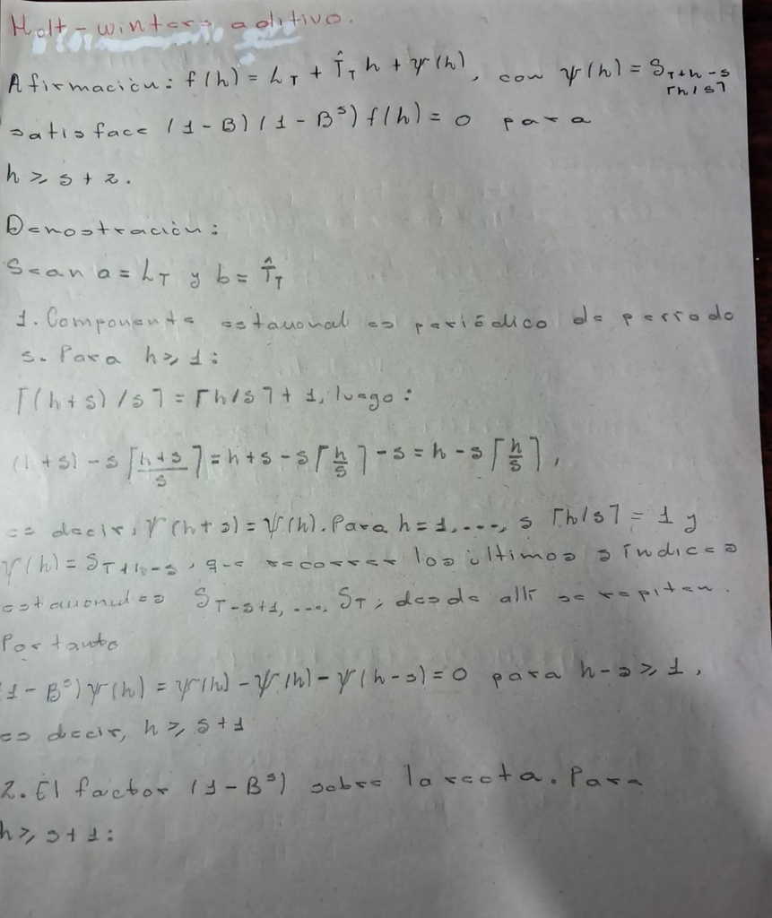

Figura 2: Demostración a mano, hoja 1: la componente estacional es periódica de período $s$ y $(1-B^s)\psi(h)=0$ para $h\ge s+1$.

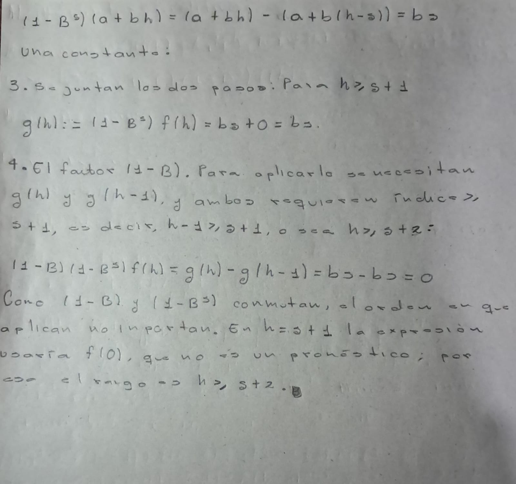

Figura 3: Demostración a mano, hoja 2: $(1-B)(1-B^s)f(h)=0$ para $h\ge s+2$.

**Solución general.** El polinomio característico se factoriza como

$$c(z)=(1-z)(1-z^s)=(1-z)^2\,(1+z+\cdots+z^{s-1}).$$

Sus raíces son:

- $z=1$, doble;
- $z_k=e^{2\pi i k/s}$, $k=1,\dots,s-1$, todas simples y de módulo 1, de período $s/k$.

Las inversas son $R_k=e^{-2\pi i k/s}$. La solución general es entonces

$$f(h)=\underbrace{b_0+b_1h}_{z=1\text{ doble}}+\underbrace{\sum_{k=1}^{s-1}c_k\,e^{-2\pi i kh/s}}_{\text{raíces } z_k}.$$

Como $f$ es real, las raíces se agrupan en pares conjugados $z_k,z_{s-k}$, cada uno con un término $e_{1k}\cos(2\pi kh/s)+e_{2k}\sin(2\pi kh/s)$; si $s$ es par, $k=s/2$ ($z=-1$) aporta $e\,(-1)^h$. Para $s=4$, el caso de la serie 2:

$$f(h)=b_0+b_1h+e_1\cos\!\left(\tfrac{\pi h}{2}\right)+e_2\sin\!\left(\tfrac{\pi h}{2}\right)+e_3(-1)^h .$$

**Qué raíces corresponden a qué.**

| Raíz de $c(z)=0$ | Módulo | Período | Componente |
| --- | --- | --- | --- |
| $z=1$, primera copia | 1 | $\infty$ | nivel $b_0$ |
| $z=1$, segunda copia (doble) | 1 | $\infty$ | tendencia lineal $b_1h$ |
| $z_k=e^{2\pi i k/s}$, $k=1,\dots,s-1$ | 1 | $s/k$ | estacionalidad: $s-1$ armónicos |

La solución tiene $s+1$ constantes libres, aunque el método carga $L_T$, $\hat T_T$ y $s$ índices estacionales ($s+2$ números). La diferencia se debe a que el nivel y el promedio de los índices estacionales no se pueden separar en la función de pronóstico: ambos viven en la raíz $z=1$, y $b_0=L_T+\frac1s\sum_{j=0}^{s-1}S_{T-j}$.

**Comprobación numérica**

Con valores arbitrarios que no provienen de las series:

**Código**

```r
local({
  H <- 20; h <- 1:H
  a <- 5; b <- 0.7                          # L_T y T_T arbitrarios
  s <- 4; S <- c(2, -1, 0.5, -1.5)          # S_{T-s+1}, ..., S_T arbitrarios
  pos  <- h - s * ceiling(h / s) + s        # posicion de S_{T+h-s*ceiling(h/s)} dentro de S
  holt <- a + b * h
  hw   <- a + b * h + S[pos]
  d2  <- holt[3:H] - 2 * holt[2:(H - 1)] + holt[1:(H - 2)]   # (1-B)^2, h = 3, ..., H
  g   <- hw[(s + 1):H] - hw[1:(H - s)]                       # (1-B^s), h = s+1, ..., H
  d1s <- g[-1] - g[-length(g)]                               # (1-B)(1-B^s), h = s+2, ..., H
  c(Holt = max(abs(d2)), `Holt-Winters` = max(abs(d1s)))
})
```

```
        Holt Holt-Winters
7.105427e-15 5.329071e-15
```

Las dos cantidades son del orden de $10^{-15}$, es decir, cero salvo error de redondeo, y los rangos de $h$ de los vectores `d2` y `d1s` son exactamente $h\ge 3$ y $h\ge s+2$.

**Conexión con 4.2.** Los factores $(1-B)$ y $(1-B^s)$ de las candidatas de 4.2 son exactamente los que anulan estas funciones de pronóstico: $(1-B)^2$ anula la recta de Holt, y $(1-B)(1-B^s)$ anula la recta más el patrón estacional de Holt–Winters. Para $s=4$, las raíces $1$ (doble), $\pm i$ y $-1$ son las mismas de la tabla de la serie 2.

# 5 Dependencia y estacionariedad

El trabajo de esta sección se hace, para cada serie, sobre la serie resultante de la transformación elegida en la sección 4: la serie 1 sin transformar, la serie 2 con $(1-B)(1-B^4)$ y la serie 3 con $\log$ y $(1-B)$.

## 5.1 ACF y PACF muestrales

La autocorrelación parcial se calcula con `pacf_dl()`, la recursión de Durbin y Levinson a partir de $r_1,\dots,r_m$. Se verificó contra `pacf()` de R con una máxima diferencia absoluta de 5e-16, menor que $10^{-10}$.

Cada gráfico lleva la banda de ruido blanco, $\pm 1{,}96/\sqrt{n}$, y en la ACF también la banda secuencial de Bartlett, $\pm 1{,}96\sqrt{\left(1+2\sum_{i<h}r_i^2\right)/n}$. Se usan $m=\min\{\lfloor n/4\rfloor,\,24\}$ rezagos, con $n$ el número de observaciones de la serie transformada.

**Serie 1: espera en estación**

**Código**

```r
b5a("serie1")
```

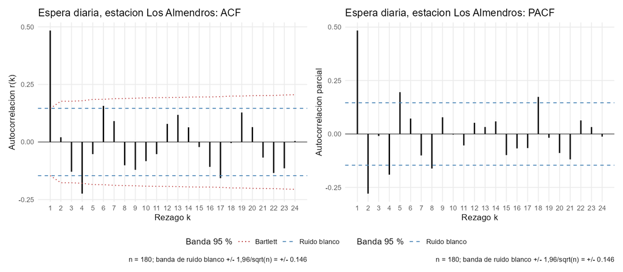

ACF (izquierda) y PACF (derecha) de la serie transformada.

| Gráfico | Banda | Rezagos fuera de la banda |
| --- | --- | --- |
| ACF | Ruido blanco | 1, 4, 6, 17 |
| ACF | Bartlett | 1, 4 |
| PACF | Ruido blanco | 1-2, 4-5, 8, 18 |

**Lectura de la ACF y la PACF.** La serie 1 no se transformó (4(c)), así que se analiza la serie original. La ACF tiene su único valor grande en el primer rezago ($r_1=0{,}48$) y después cae rápido: no decae lentamente, como ocurriría con una tendencia, ni se repite cada 7 días, como ocurriría con una estacionalidad semanal. Fuera de la banda de ruido blanco quedan los rezagos 1, 4, 6 y 17; con la banda de Bartlett solo 1 y 4. Entre 24 rezagos es esperable que alguno salga por azar, de modo que 6 y 17 no se leen como estructura. La PACF es significativa en los rezagos 1 y 2 (con $\hat\phi_{11}=0{,}48$ y $\hat\phi_{22}\approx-0{,}28$) y en 4 y 5, y no se corta de forma clara: tiene valores significativos de signos alternados. La serie es consistente con nivel estable y dependencia de corto plazo, que se contrasta con los bloques de 5.3.

**Qué pregunta responde cada banda.** La banda de ruido blanco, $\pm1{,}96/\sqrt n=\pm0{,}146$, responde si una autocorrelación es distinta de cero si la serie fuera ruido blanco: un rezago dentro de ella no se distingue de cero con estos datos. La banda de Bartlett responde hasta qué rezago llega la autocorrelación, es decir, si la ACF se corta; es más ancha en los rezagos mayores porque tiene en cuenta la autocorrelación ya observada en los menores, y por eso deja fuera menos rezagos (1 y 4). Para la PACF se usa la banda de ruido blanco, y responde si la PACF se corta después de un rezago $p$.

**Serie 2: pasajeros del aeropuerto**

**Código**

```r
b5a("serie2")
```

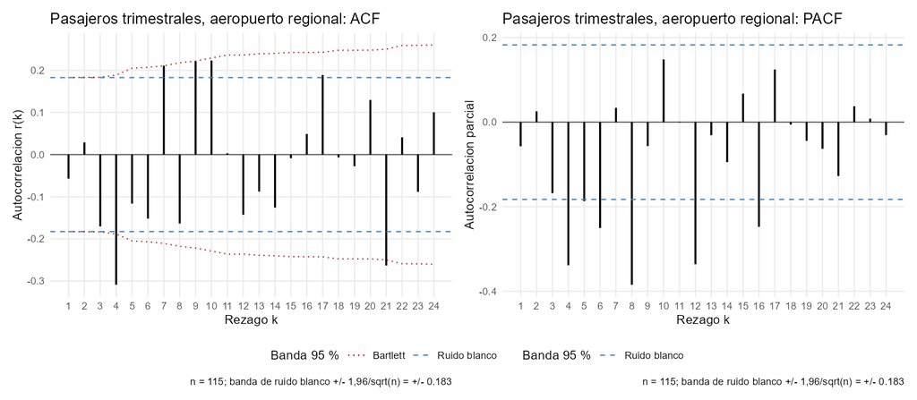

ACF (izquierda) y PACF (derecha) de la serie transformada.

| Gráfico | Banda | Rezagos fuera de la banda |
| --- | --- | --- |
| ACF | Ruido blanco | 4, 7, 9-10, 17, 21 |
| ACF | Bartlett | 4, 21 |
| PACF | Ruido blanco | 4-6, 8, 12, 16 |

**Lectura de la ACF y la PACF.** La serie 2 se transformó con $(1-B)(1-B^4)$ (4(c)), así que se analizan los $n=115$ valores de la serie diferenciada. La tendencia desapareció: la ACF ya no decae lentamente, y $r_1=-0{,}06$ queda dentro de la banda, es decir, trimestres consecutivos no están autocorrelacionados. Lo que queda es dependencia en el rezago estacional: $r_4\approx-0{,}31$ es el valor más grande y sale de las dos bandas. Fuera de la banda de ruido blanco quedan los rezagos 4, 7, 9, 10, 17 y 21; con la de Bartlett solo 4 y 21, de modo que los rezagos 7, 9, 10 y 17, de tamaño apenas mayor a la banda, no se leen como estructura. La PACF es significativa y negativa en los múltiplos de 4 ($\hat\phi_{44}\approx-0{,}34$, $\hat\phi_{88}\approx-0{,}38$, $\hat\phi_{12,12}\approx-0{,}33$ y $\hat\phi_{16,16}\approx-0{,}25$) y no se corta: decae lentamente a lo largo de esos rezagos. Un pico único en la ACF en $k=4$ junto con una PACF que decae en los múltiplos de 4 es la forma de una media móvil estacional.

**Qué pregunta responde cada banda.** La banda de ruido blanco, $\pm1{,}96/\sqrt{n}=\pm0{,}183$; sirve para el rezago 1, que queda dentro, y como referencia general. La de Bartlett responde hasta qué rezago llega la autocorrelación, es decir, si la ACF se corta: al ser más ancha en los rezagos mayores, deja solo 4 y 21, y el rezago 4 es el que sobresale con claridad. Para la PACF se usa la banda de ruido blanco, y responde si la PACF se corta después de un rezago $p$; aquí no se corta en los múltiplos de 4.

**Serie 3: viajes de la plataforma**

**Código**

```r
b5a("serie3")
```

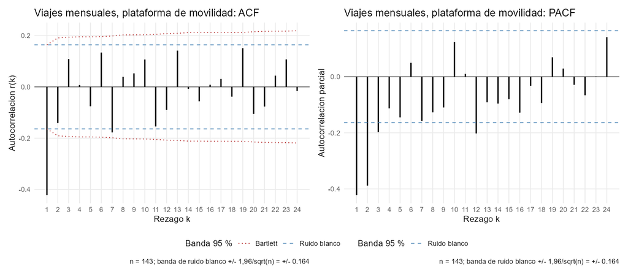

ACF (izquierda) y PACF (derecha) de la serie transformada.

| Gráfico | Banda | Rezagos fuera de la banda |
| --- | --- | --- |
| ACF | Ruido blanco | 1, 7 |
| ACF | Bartlett | 1 |
| PACF | Ruido blanco | 1-3, 12 |

**Lectura de la ACF y la PACF.** La serie 3 se transformó con $\log$ y $(1-B)$ (4(c)), así que se analizan los $n=143$ valores de $\nabla\log Y_t$. La ACF tiene un único pico grande y negativo en el primer rezago, $r_1\approx-0{,}42$, fuera de las dos bandas; después casi todos los rezagos quedan dentro. Fuera de la banda de ruido blanco ($\pm0{,}164$) están los rezagos 1 y 7, y con la de Bartlett solo el 1: el rezago 7 ($r_7\approx-0{,}18$) no tiene lectura en una serie mensual y se atribuye al azar entre 24 rezagos. La PACF es significativa en los rezagos 1, 2, 3 y 12, con valores negativos que decrecen ($\hat\phi_{11}\approx-0{,}42$, $\hat\phi_{22}\approx-0{,}39$, $\hat\phi_{33}\approx-0{,}20$); no se corta. Por tanto hay dependencia de corto plazo, y de un solo mes, y no de largo plazo. Una ACF que se corta tras el rezago 1 y una PACF que decae con el mismo signo es la forma de una media móvil de orden 1 con coeficiente negativo. El rezago 12 de la PACF ($\hat\phi_{12,12}\approx-0{,}20$) está aislado y la ACF no sale en 12, lo que concuerda con que no se atribuyó estacionalidad en 3(b).

**Qué pregunta responde cada banda.** La banda de ruido blanco, $\pm1{,}96/\sqrt{n}=\pm0{,}164$; deja fuera los rezagos 1 y 7. La de Bartlett es más ancha y deja fuera solo el rezago 1, así que la ACF se corta en 1. Para la PACF se usa la banda de ruido blanco, y responde si se corta después de un rezago $p$; aquí no se corta y decae.

## 5.2 Prueba de Ljung–Box y procesos compatibles

La prueba de Ljung–Box contrasta que las primeras $m$ autocorrelaciones son nulas,

$$Q_m=n(n+2)\sum_{k=1}^{m}\frac{r_k^2}{n-k}\;\sim\;\chi^2_{m}\quad\text{bajo }H_0,$$

con $m$ grados de libertad porque no hay parámetros estimados. Para decidir con qué proceso es compatible la forma de la ACF y la PACF se usan las firmas teóricas de las clases 3 y 8.

| Proceso | ACF | PACF |
| --- | --- | --- |
| Ruido blanco | cero en todos los rezagos | cero en todos los rezagos |
| AR($p$) | decae (exponencial o sinusoidal amortiguada) | se corta después del rezago $p$ |
| MA($q$) | se corta después del rezago $q$ | decae |
| ARMA($p,q$) | decae | decae |
| Raíz unitaria (paseo aleatorio) | decae muy lentamente, cerca de 1 | $\phi_{11}\approx 1$ y el resto cerca de 0 |

**Serie 1: espera en estación**

**Código**

```r
b5b("serie1")
```

**Prueba de Ljung–Box** con $m=14$ rezagos y 14 grados de libertad (no se restan parámetros: la serie transformada no viene de un modelo ajustado).

| Elemento | Contenido |
| --- | --- |
| 1. Hipotesis | H0: rho(1) = … = rho(14) = 0; H1: rho(k) != 0 para algun k en 1, …, 14 |
| 2. Estadistico y distribucion | Q = n(n+2) sum_{k=1}^{m} r_k^2/(n-k) ~ chi-cuadrado con 14 g.l. bajo H0 |
| 3. Region de rechazo (5 %) | Q > 23.685 |
| 4. Observado y valor p | observado = 73.4167; valor p = 4.613e-10 |
| 5. Decision | Se rechaza H0 al 5 % |
| 6. Lectura | Hay autocorrelacion conjunta significativa en los primeros 14 rezagos de la serie transformada (Espera diaria, estacion Los Almendros). |

**Sensibilidad al valor de $m$.**

| m | Q | g.l. | Valor crítico | Valor p |
| --- | --- | --- | --- | --- |
| 5 | 55.893 | 5 | 11.070 | 8.55e-11 |
| 7 | 62.079 | 7 | 14.067 | 5.80e-11 |
| 10 | 68.149 | 10 | 18.307 | 1.01e-10 |
| 14 | 73.417 | 14 | 23.685 | 4.61e-10 |
| 24 | 92.392 | 24 | 36.415 | 5.77e-10 |

**Elección y justificación de $m$.** Se usó $m=14$, es decir, dos semanas: la serie es diaria, el ciclo natural es la semana y con 14 rezagos se cubren los rezagos 7 y 14, donde aparecería una dependencia semanal. La elección no cambia la decisión: con $m=5,7,10,14$ y $24$ el valor p es menor que $10^{-9}$ y se rechaza $H_0$ en todos los casos.

**Procesos compatibles y no compatibles.** La prueba rechaza $H_0$, así que la serie no es ruido blanco y el pasado ayuda a explicar el presente. La forma de la ACF y la PACF dice de qué tipo es esa dependencia. La ACF tiene un único pico en el rezago 1 ($r_1=0{,}48$) y luego $r_2=0{,}02$, dentro de la banda; la PACF, con $\hat\phi_{11}=0{,}48$ y $\hat\phi_{22}\approx-0{,}28$, alterna de signo y no se corta. Esto es compatible con un MA(1) con coeficiente positivo: $\rho_1=\theta/(1+\theta^2)=0{,}48$ implica $\theta\approx0{,}75$, y con ese valor la PACF teórica sería $\phi_{22}\approx-0{,}30$, cerca de lo observado. En términos de la serie, una espera alta un día tiende a seguirse de otra alta al día siguiente, y el efecto desaparece desde el segundo día. No es compatible con ruido blanco (Ljung–Box); con un AR(1) ($\phi=0{,}48$ daría $\rho_2\approx0{,}23$ y una PACF que se corta en 1, pero se observa $r_2=0{,}02$ y $\hat\phi_{22}$ fuera de la banda); con una estacionalidad semanal ($r_7=0{,}09$, dentro de la banda); ni con una raíz unitaria o una tendencia (la ACF cae de inmediato en lugar de decaer despacio).

**Serie 2: pasajeros del aeropuerto**

**Código**

```r
b5b("serie2")
```

**Prueba de Ljung–Box** con $m=8$ rezagos y 8 grados de libertad (no se restan parámetros: la serie transformada no viene de un modelo ajustado).

| Elemento | Contenido |
| --- | --- |
| 1. Hipotesis | H0: rho(1) = … = rho(8) = 0; H1: rho(k) != 0 para algun k en 1, …, 8 |
| 2. Estadistico y distribucion | Q = n(n+2) sum_{k=1}^{m} r_k^2/(n-k) ~ chi-cuadrado con 8 g.l. bajo H0 |
| 3. Region de rechazo (5 %) | Q > 15.507 |
| 4. Observado y valor p | observado = 28.9456; valor p = 0.0003241 |
| 5. Decision | Se rechaza H0 al 5 % |
| 6. Lectura | Hay autocorrelacion conjunta significativa en los primeros 8 rezagos de la serie transformada (Pasajeros trimestrales, aeropuerto regional). |

**Sensibilidad al valor de $m$.**

| m | Q | g.l. | Valor crítico | Valor p |
| --- | --- | --- | --- | --- |
| 4 | 15.539 | 4 | 9.488 | 0.003705 |
| 5 | 17.195 | 5 | 11.070 | 0.004144 |
| 8 | 28.946 | 8 | 15.507 | 0.000324 |
| 10 | 41.569 | 10 | 18.307 | 8.95e-06 |
| 24 | 67.876 | 24 | 36.415 | 4.57e-06 |

**Elección y justificación de $m$.** Se usó $m=8$, es decir, dos años: la serie es trimestral, el ciclo natural es el año (cuatro trimestres) y con 8 rezagos se cubren los rezagos 4 y 8, donde aparece la dependencia estacional. El estadístico $Q$ suma los cuadrados de las autocorrelaciones, por lo que crece con $m$ cuando se agregan rezagos con autocorrelación: pasa de 15,5 ($m=4$, $p=0{,}0037$) a 28,9 ($m=8$, $p=3{,}2\times10^{-4}$) y a 41,6 ($m=10$, $p=9\times10^{-6}$). Lo que sostiene la elección es que la decisión no depende de $m$: con $m=4,5,8,10$ y $24$ se rechaza $H_0$ al 5 %.

**Procesos compatibles y no compatibles.** La prueba rechaza $H_0$, de modo que la serie transformada no es ruido blanco. La ACF tiene un pico único y negativo en el rezago estacional ($r_4\approx-0{,}31$, fuera de las dos bandas), mientras $r_1=-0{,}06$ queda dentro; el rezago 10 sobresale solo de la banda de ruido blanco y no se interpreta. La PACF es negativa y significativa en los múltiplos de 4 ($\hat\phi_{44}\approx-0{,}34$, $\hat\phi_{88}\approx-0{,}38$, $\hat\phi_{12,12}\approx-0{,}33$, $\hat\phi_{16,16}\approx-0{,}25$). Esa forma es compatible con una media móvil estacional de período 4 con coeficiente negativo. El ajuste es solo cualitativo: $r_4=-0{,}31$ implica $\theta\approx-0{,}35$ y una PACF teórica que decaería rápido ($\phi_{88}\approx-0{,}11$), mientras que la observada se mantiene entre $-0{,}25$ y $-0{,}38$, lo que indica una dependencia estacional más persistente. No es compatible con ruido blanco (Ljung–Box); con un AR de orden bajo (la PACF no se corta); con un MA(1) no estacional (no hay pico en 1); con un AR estacional (daría $\rho_8\approx+0{,}1$ y se observa $r_8\approx-0{,}16$, y su PACF se cortaría en 4); ni con tendencia o raíz unitaria (la ACF no decae lentamente).

**Serie 3: viajes de la plataforma**

**Código**

```r
b5b("serie3")
```

**Prueba de Ljung–Box** con $m=24$ rezagos y 24 grados de libertad (no se restan parámetros: la serie transformada no viene de un modelo ajustado).

| Elemento | Contenido |
| --- | --- |
| 1. Hipotesis | H0: rho(1) = … = rho(24) = 0; H1: rho(k) != 0 para algun k en 1, …, 24 |
| 2. Estadistico y distribucion | Q = n(n+2) sum_{k=1}^{m} r_k^2/(n-k) ~ chi-cuadrado con 24 g.l. bajo H0 |
| 3. Region de rechazo (5 %) | Q > 36.415 |
| 4. Observado y valor p | observado = 59.6364; valor p = 7.188e-05 |
| 5. Decision | Se rechaza H0 al 5 % |
| 6. Lectura | Hay autocorrelacion conjunta significativa en los primeros 24 rezagos de la serie transformada (Viajes mensuales, plataforma de movilidad). |

**Sensibilidad al valor de $m$.**

| m | Q | g.l. | Valor crítico | Valor p |
| --- | --- | --- | --- | --- |
| 5 | 31.519 | 5 | 11.070 | 7.40e-06 |
| 10 | 41.468 | 10 | 18.307 | 9.32e-06 |
| 12 | 46.485 | 12 | 21.026 | 5.72e-06 |
| 24 | 59.636 | 24 | 36.415 | 7.19e-05 |

**Elección y justificación de $m$.** Se usó $m=24$, es decir, dos años: la serie es mensual, el ciclo natural es el año (12 meses) y con 24 rezagos se cubren los rezagos 12 y 24, donde aparecería una estacionalidad anual. La elección no cambia la decisión: con $m=5,10,12$ y $24$ el valor p es menor que $10^{-4}$ y se rechaza $H_0$ en todos los casos. La evidencia viene casi toda del primer rezago (con $m=5$ ya se tiene $Q=31{,}5$); al aumentar $m$ hasta 24 el valor p sube un poco, de $5{,}7\times10^{-6}$ ($m=12$) a $7{,}2\times10^{-5}$, porque se suman muchos rezagos sin autocorrelación que diluyen la prueba.

**Procesos compatibles y no compatibles.** La prueba rechaza $H_0$: la serie transformada no es ruido blanco, y la dependencia es de un solo mes. La ACF se corta en el rezago 1 ($r_1\approx-0{,}42$, con $r_2$ dentro de la banda) y la PACF decae con signo negativo ($\hat\phi_{11}\approx-0{,}42$, $\hat\phi_{22}\approx-0{,}39$, $\hat\phi_{33}\approx-0{,}20$), que es la forma de un MA(1) con coeficiente negativo. En términos de la serie, un mes con crecimiento por encima de lo normal tiende a ir seguido de uno por debajo. El ajuste es cualitativo: $r_1=-0{,}42$ implica $\theta\approx-0{,}54$ y una PACF teórica de $\phi_{22}\approx-0{,}21$, menor que el $-0{,}39$ observado, es decir, la PACF observada decae más lentamente, lo que indica un coeficiente más cercano a $-1$. Un $r_1$ cercano a $-0{,}5$ es también lo que se obtiene al diferenciar una tendencia determinista más ruido, lo que concuerda con la cautela de 4(c) y con 6(b). No es compatible con ruido blanco (Ljung–Box); con un AR(1) (su PACF se cortaría en 1, pero $\hat\phi_{22}$ y $\hat\phi_{33}$ salen de la banda, y daría $\rho_2\approx+0{,}18$ frente al $r_2\approx-0{,}14$ observado); con una estacionalidad anual ($r_{12}\approx-0{,}09$, dentro de la banda; el $\hat\phi_{12,12}\approx-0{,}20$ aislado no se interpreta); ni con un paseo aleatorio, que ya se eliminó con $(1-B)$ y cuya ACF decaería despacio.

## 5.3 Estacionariedad y ergodicidad

Cada serie transformada se divide en cuatro bloques consecutivos de igual tamaño (salvo una observación) y se compara su media y su varianza. La media se estima con dos errores estándar. El ingenuo supone observaciones incorrelacionadas, $\hat\sigma/\sqrt{n}$. El de largo plazo usa la varianza de largo plazo con núcleo de Bartlett,

$$\hat\sigma^2_{LP}=\hat\gamma(0)+2\sum_{k=1}^{L}\left(1-\frac{k}{L+1}\right)\hat\gamma(k),\qquad L=\left\lfloor 4\left(\frac{n}{100}\right)^{2/9}\right\rfloor,$$

y su error estándar es $\hat\sigma_{LP}/\sqrt{n}$.

**Serie 1: espera en estación**

**Código**

```r
b5c("serie1")
```

**Media y varianza por bloque.**

| Bloque | n | Desde | Hasta | Media | Varianza | Desv. estándar |
| --- | --- | --- | --- | --- | --- | --- |
| 1 | 45 | 2025-04-07 | 2025-05-21 | 298.8889 | 395.6010 | 19.8897 |
| 2 | 45 | 2025-05-22 | 2025-07-05 | 295.8222 | 268.8768 | 16.3975 |
| 3 | 45 | 2025-07-06 | 2025-08-19 | 300.8000 | 309.6182 | 17.5960 |
| 4 | 45 | 2025-08-20 | 2025-10-03 | 299.5556 | 328.5707 | 18.1265 |

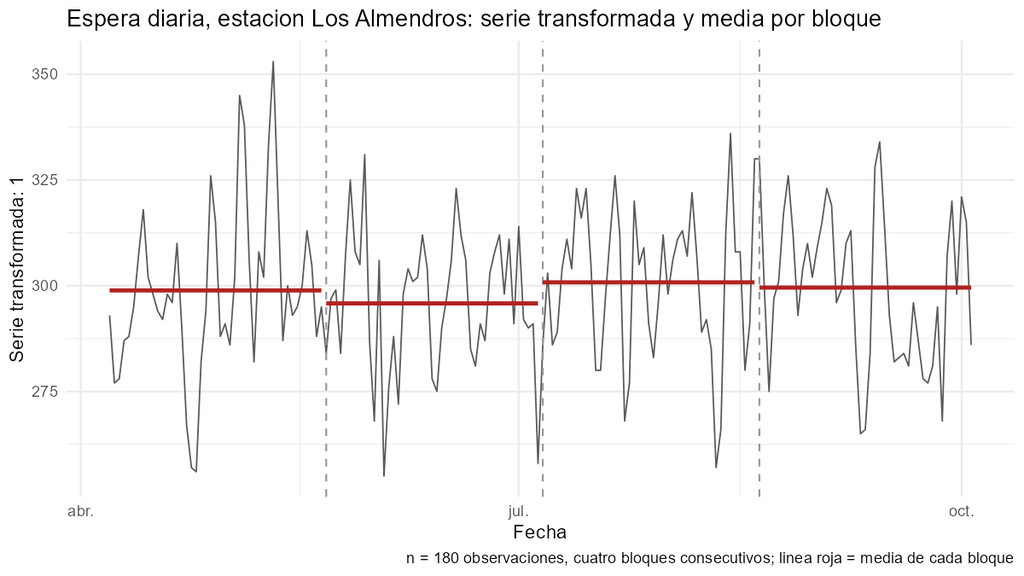

Serie transformada y media de cada bloque.

**Media con dos errores estándar** (media = 298,7667; $L=4$).

| Error estándar | Valor | IC 95 % inferior | IC 95 % superior |
| --- | --- | --- | --- |
| Ingenuo, $\hat\sigma/\sqrt{n}$ | 1.3408 | 296.1387 | 301.3946 |
| Largo plazo, núcleo de Bartlett | 1.6946 | 295.4452 | 302.0881 |

Razón de errores estándar (largo plazo / ingenuo): 1,26.

**Estacionariedad por bloques.** La serie 1 es compatible con estacionariedad: en los cuatro bloques consecutivos la media se mantiene en torno a un mismo nivel (entre 295,8 y 300,8 s) y la varianza oscila entre 268,9 y 395,6 s² sin un patrón creciente ni decreciente.

**Los dos errores estándar: por qué difieren y cuál es el adecuado.** El error estándar ingenuo es 1,341 s y el de largo plazo es 1,695 s. Difieren porque el ingenuo supone observaciones incorrelacionadas, mientras que la serie tiene autocorrelación positiva ($r_1=0,48$): los datos vecinos repiten información y la media es menos precisa de lo que el ingenuo supone. El de largo plazo incorpora esa dependencia a través de las autocovarianzas, y por eso es mayor (razón de 1,26). El adecuado es el de largo plazo: el ingenuo subestima la incertidumbre y da un intervalo del 95 % más estrecho ([296,1; 301,4]) que el de largo plazo ([295,4; 302,1]).

**Qué representa la media en términos de la serie original.** Como la serie 1 no se transformó, la media de 298,8 s es el nivel medio del tiempo de espera diario en la estación, y tiene sentido hablar de una sola media porque la serie es estacionaria. Con el intervalo de largo plazo, ese nivel queda por debajo de la meta de 330 s.

**Serie 2: pasajeros del aeropuerto**

**Código**

```r
b5c("serie2")
```

**Media y varianza por bloque.**

| Bloque | n | Desde | Hasta | Media | Varianza | Desv. estándar |
| --- | --- | --- | --- | --- | --- | --- |
| 1 | 28 | 1997-04-01 | 2004-01-01 | 5.2821 | 3288.060 | 57.3416 |
| 2 | 29 | 2004-04-01 | 2011-04-01 | 2.6552 | 5574.416 | 74.6620 |
| 3 | 29 | 2011-07-01 | 2018-07-01 | -3.6034 | 5683.383 | 75.3882 |
| 4 | 29 | 2018-10-01 | 2025-10-01 | -1.9241 | 2551.911 | 50.5164 |

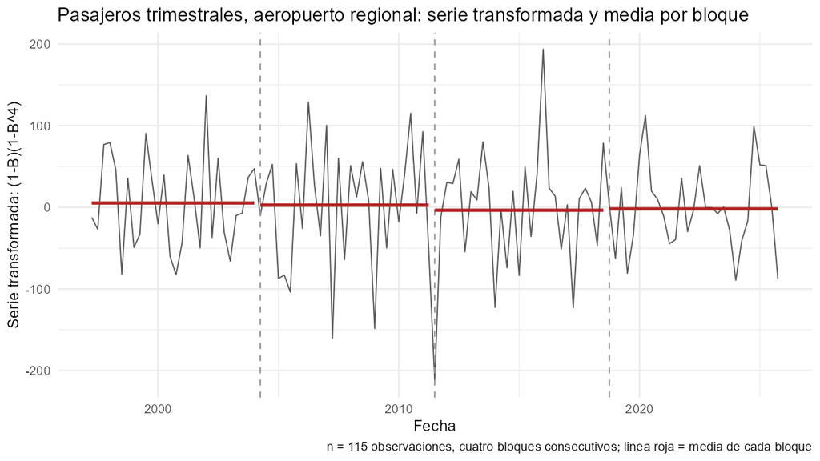

Serie transformada y media de cada bloque.

**Media con dos errores estándar** (media = 0,5617; $L=4$).

| Error estándar | Valor | IC 95 % inferior | IC 95 % superior |
| --- | --- | --- | --- |
| Ingenuo, $\hat\sigma/\sqrt{n}$ | 6.0312 | -11.2594 | 12.3829 |
| Largo plazo, núcleo de Bartlett | 4.9633 | -9.1663 | 10.2898 |

Razón de errores estándar (largo plazo / ingenuo): 0,82.

**Estacionariedad por bloques.** La media de los cuatro bloques va de -3,6 a 5,3, una diferencia pequeña frente al error estándar de cada media (de 9,4 a 14,0), por lo que es compatible con una constante cercana a cero. La varianza cambia más: va de 2552 a 5683 (cociente de 2,23), con valores mayores en los bloques centrales. La serie es aproximadamente estacionaria en media, con una variabilidad algo cambiante.

**Los dos errores estándar: por qué difieren y cuál es el adecuado.** El error estándar ingenuo es 6,03 y el de largo plazo es 4,96 miles de pasajeros. Difieren porque la serie transformada tiene autocorrelaciones negativas en los primeros rezagos ($r_3=-0,17$ y $r_4=-0,31$, esta última fuera de la banda), y al sumarlas la varianza de largo plazo queda por debajo de $\hat\gamma(0)$ (factor de 0,68). El adecuado es el de largo plazo, porque incorpora esa dependencia que el ingenuo ignora; sus intervalos del 95 % son [-9,2; 10,3] (largo plazo) y [-11,3; 12,4] (ingenuo).

**Qué representa la media en términos de la serie original.** La serie transformada es $(1-B)(1-B^4)Y_t=(Y_t-Y_{t-4})-(Y_{t-1}-Y_{t-5})$, el cambio entre un trimestre y el siguiente de la diferencia interanual. Su media, 0,56 en miles de pasajeros (unos 562 pasajeros), no es un nivel de pasajeros. Si la serie tuviera una tendencia lineal y una estacionalidad fija, esa media sería 0; el intervalo de largo plazo contiene el 0, de modo que los datos no contradicen esa descripción.

**Serie 3: viajes de la plataforma**

**Código**

```r
b5c("serie3")
```

**Media y varianza por bloque.**

| Bloque | n | Desde | Hasta | Media | Varianza | Desv. estándar |
| --- | --- | --- | --- | --- | --- | --- |
| 1 | 35 | 2014-02-01 | 2016-12-01 | 0.0105 | 0.0034 | 0.0579 |
| 2 | 36 | 2017-01-01 | 2019-12-01 | 0.0147 | 0.0020 | 0.0452 |
| 3 | 36 | 2020-01-01 | 2022-12-01 | 0.0106 | 0.0027 | 0.0519 |
| 4 | 36 | 2023-01-01 | 2025-12-01 | 0.0136 | 0.0029 | 0.0538 |

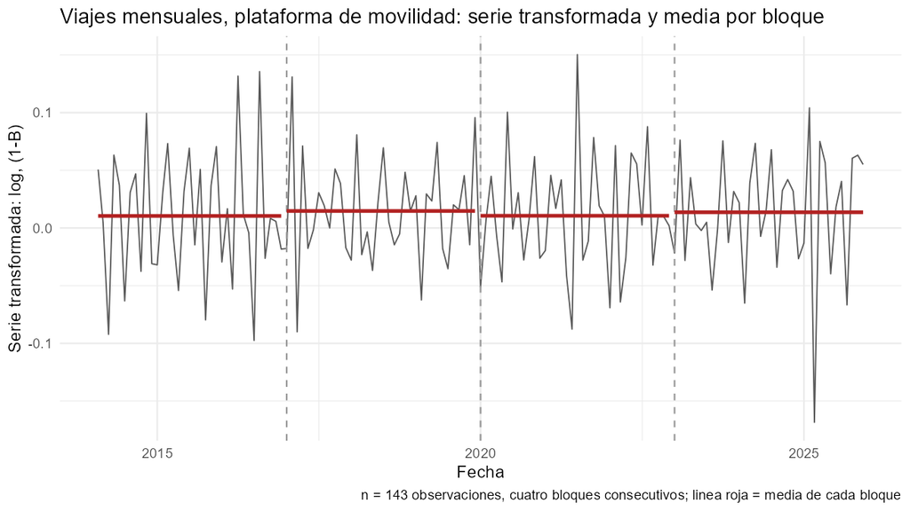

Serie transformada y media de cada bloque.

**Media con dos errores estándar** (media = 0,0124; $L=4$).

| Error estándar | Valor | IC 95 % inferior | IC 95 % superior |
| --- | --- | --- | --- |
| Ingenuo, $\hat\sigma/\sqrt{n}$ | 0.0043 | 0.0039 | 0.0209 |
| Largo plazo, núcleo de Bartlett | 0.0021 | 0.0082 | 0.0166 |

Razón de errores estándar (largo plazo / ingenuo): 0,49.

**Estacionariedad por bloques.** La media de los cuatro bloques va de 0,0105 a 0,0147, una diferencia menor que el error estándar de cada media (de 0,0075 a 0,0098), y la varianza va de 0,0020 a 0,0034 sin un patrón creciente ni decreciente. La serie transformada es compatible con estacionariedad.

**Los dos errores estándar: por qué difieren y cuál es el adecuado.** El error estándar ingenuo es 0,0043 y el de largo plazo es 0,0021, la mitad. Difieren porque la autocorrelación en el rezago 1 es fuerte y negativa ($r_1=-0,42$), de modo que al sumarla la varianza de largo plazo queda en solo el 25 % de $\hat\gamma(0)$. Además, la media de $\nabla\log Y_t$ es $(\log Y_T-\log Y_1)/(T-1)$, depende solo del primer y del último dato, y por eso se estima con mucha más precisión de la que supone el ingenuo. El adecuado es el de largo plazo, con intervalo del 95 % de [0,0082; 0,0166].

**Qué representa la media en términos de la serie original.** La media de $\nabla\log Y_t$ es la tasa media de crecimiento mensual: 1,24 % al mes, es decir, un crecimiento anual cercano a 16,0 %. Con el intervalo de largo plazo, el crecimiento anual estaría entre 10,3 % y 22,0 %.

# 6 Pronóstico y evaluación

## 6.1 Métodos y asignación

Cada método del catálogo está en su propia función de `R/04-metodos.R`. Todas reciben solo $y_1,\dots,y_o$ y devuelven el pronóstico a un paso dentro de muestra (`yhat`, que en $t$ usa solo $y_1,\dots,y_{t-1}$) y una función `pronosticar(h)`. Los métodos se aplican a la **serie original**, en sus unidades, porque cada uno trae su propio supuesto sobre nivel, tendencia y estacionalidad. La transformación de la sección 4 no se pronostica: sirve de diagnóstico para decidir qué supuestos sostienen los datos. En los métodos no se usan `HoltWinters()`, `filter()`, `decompose()` ni `lm()`; las regresiones se resuelven por mínimos cuadrados con `qr()`.

### 6.1.1 Convenciones de inicialización

Son las de las notas de clase. La tabla de verificación de abajo muestra que con ellas se reproducen las cifras publicadas.

| Método | Pronóstico a un paso | Inicialización (notas) | Primer pronóstico |
| --- | --- | --- | --- |
| Media simple | $\hat Y_{t+1}=\frac1t\sum_{i\le t}Y_i$ (media recursiva, sin fuga de información) | — | $t=2$ |
| Ingenuo | $\hat Y_{t+1}=Y_t$ | — | $t=2$ |
| Ingenuo estacional | $\hat Y_{t+1}=Y_{t+1-s}$ | — | $t=s+1$ |
| Media móvil | $\hat Y_{t+1}=MM_t(k)$ | $MM_t(k)$ existe desde $t=k$ | $t=k+1$ |
| SES | $\hat Y_{t+1}=\alpha Y_t+(1-\alpha)\hat Y_t$ | $\hat Y_2=Y_1$ | $t=2$ |
| Doble media móvil | $\hat Y_{t+1}=\hat E_t+\hat\beta_1(t)$, con $\hat E_t=2MM_t-DMM_t$ y $\hat\beta_1(t)=\frac{2}{k-1}(MM_t-DMM_t)$ | $DMM_t$ existe desde $t=2k-1$ | $t=2k$ |
| Tendencias (lineal, cuadrática, exponencial) | recta, parábola o $e^{\hat a+\hat\theta t}$ ajustada con $y_1,\dots,y_{t-1}$ | ventana creciente; la exponencial se retransforma con el factor de Duan $\frac1n\sum e^{\hat\varepsilon_t}$ | $t=p+2$ ($p$ coeficientes) |
| Tendencia con ficticias de suma cero | $\hat\beta_0+\hat\beta_1t+\hat\gamma_j$, $\sum_j\hat\gamma_j=0$ | ventana creciente; estación 1 = lunes, primer trimestre o enero | $t=s+3$ |
| Holt | $\hat Y_{t+1}=L_t+\hat T_t$ | $L_1=Y_1$, $\hat T_1=0$ | $t=2$ |
| Holt–Winters aditivo y multiplicativo | $L_{t-1}+b_{t-1}+S_{t-s}$, o $(L_{t-1}+b_{t-1})S_{t-s}$ | con $m=\lfloor n/s\rfloor$ ciclos y sus promedios $\bar y_i$: $b_0=\frac{\bar y_m-\bar y_1}{(m-1)s}$, $L_0=\bar y_1-b_0\frac{s-1}{2}$, $S_{0,j}$ = promedio de $Y_t-(L_0+b_0(t-1))$ (o del cociente) en … | $t=1$ |

Dos decisiones merecen nota. La tendencia exponencial usa el factor de Duan porque $e^{\hat a+\hat\theta t}$ estima la mediana condicional y no la media (clase 4, proposición 4). En Holt–Winters el estado $(L_0,b_0)$ corresponde a $t=0$ y $S_{0,j}$ es el índice que usa el período $t=j$; con esa lectura se reproduce el paso $t=5$ de la clase 5.

### 6.1.2 Verificación de cada método

El bloque V6 de `correr-todo.R` contrasta cada función contra una cifra de las notas o contra un cálculo a mano, y detiene la ejecución con `stopifnot()` si alguna no coincide. `lm()` solo aparece allí, como verificación.

**Código**

```r
res$verif6 |>
  dplyr::transmute(`Método` = metodo, `Contra qué` = contra, `Cifra de referencia` = cifra_notas,
                   `Obtenido` = gsub(".", ",", obtenido, fixed = TRUE),
                   `¿Coincide?` = ifelse(verificado, "Sí", "No")) |>
  knitr::kable()
```

Tabla 16: Verificación de los métodos de pronóstico contra las notas de clase o contra cálculos a mano.

| Método | Contra qué | Cifra de referencia | Obtenido | ¿Coincide? |
| --- | --- | --- | --- | --- |
| ingenuo | Clase 9, ejemplo 1: fila B x_t | NA 4 7 6 9 12 | NA 4 7 6 9 12 | Sí |
| ingenuo estacional | Clase 9, ejemplo 1: fila B^2 x_t (s = 2) | NA NA 4 7 6 9 | NA NA 4 7 6 9 | Sí |
| media simple | A mano sobre el ejemplo 1: 4; 5,5; 5,667; 6,5; 7,6 | media de y1..y(t-1) | NA 4 5,5 5,667 6,5 7,6 | Sí |
| media movil | Clase 3, diap. 45: MM(3), MSE, MAD, MAPE y pronostico de enero | N = 5; 1,1621; 0,9780; 4,607 %; 21,5230 | N = 5; 1,1621; 0,9780; 4,607 %; 21,5233 | Sí |
| SES | Clase 3, diap. 37: SES(0,15), N = 7 y MSE en origen comun t = 4..8 | N = 7; 2,8534; 1,5895; 7,609 %; comun 3,3706 | N = 7; 2,8534; 1,5895; 7,609 %; comun 3,3706 | Sí |
| doble media movil | Clase 4, diap. 66: DMM(3), N, MSE, MAD y 3 pronosticos | N = 6; 841,24; 28,20; 356,56 370,00 383,44 | N = 6; 841,24; 28,20; 356,56 370,00 383,44 | Sí |
| Holt | Clase 4, diap. 66: Holt(0,3; 0,4), columna Yhat, MSE, MAD y 3 pronosticos | N = 10; 1133,08; 28,62; 387,15 414,97 442,80 | N = 10; 1133,08; 28,62; 387,15 414,97 442,80 | Sí |
| tendencia con ficticias | Clase 4, diap. 53 y 55: coeficientes y Yhat_17..20 | 6,6644 0,0262 \| -5,2481 -2,2494 1,7494 5,7481 \| 1,863 4,887 8,912 12,938 | 6,6644 0,0262 -5,2481 -2,2494 1,7494 5,7481 | Sí |
| tendencia lineal | lm() de R: coeficientes, pronosticos 12..14 y yhat_9 con y1..y8 | 98.4727 23.3455 | 98,4727 23,3455 | Sí |
| tendencia cuadratica | lm() de R: coeficientes, pronosticos 12..14 y yhat_9 con y1..y8 | 103.6242 20.9678 0.1981 | 103,6242 20,9678 0,1981 | Sí |
| tendencia exponencial | lm() de R: coeficientes, pronosticos 12..14 y yhat_9 con y1..y8 | 4.8074 0.1024 | 4,8074 0,1024 | Sí |
| regresion_mco() (6b) | summary(lm()) con contr.sum: coeficientes y e.e. ordinario; HAC con L = 0 = White | 0.2051 0.0214 0.1684 0.1657 0.1657 | 0,2051 0,0214 0,1684 0,1657 0,1657 | Sí |
| Holt-Winters aditivo | Clase 5, diap. 54: L4, b4, S1, Yhat5, L5, b5, S5 | 6,8650 0,0326 -5,2471 1,6505 6,9425 0,0348 -5,2157 | 6,8650 0,0326 -5,2471 1,6505 6,9425 0,0348 -5,2157 | Sí |
| Holt-Winters multiplicativo | A mano sobre las ventas: L0, b0, S0_1, Yhat1, L1, b1, S1, Yhat2 | 6.7500 0.0333 0.2346 1.5914 6.6665 0.0275 0.2317 4.5160 | 6,7500 0,0333 0,2346 1,5914 6,6665 0,0275 0,2317 4,5160 | Sí |
| Holt-Winters aditivo | Clase 5, prop. 8: con alpha = beta = gamma = 0, Yhat_t = L0 + b0 t + S0_j | diferencia 0 | 1,8e-15 | Sí |

Las series de juguete son las de las notas: el ejemplo 1 de la clase 9 ($x_t=4,7,6,9,12,10$), los ocho precios de una acción de la clase 3, los once créditos al consumo y las dieciséis ventas trimestrales de las clases 4 y 5. En la media simple la cuenta a mano es $\hat Y_3=(4+7)/2=5{,}5$, $\hat Y_4=17/3=5{,}667$, $\hat Y_5=26/4=6{,}5$ y $\hat Y_6=38/5=7{,}6$. El Holt–Winters multiplicativo no tiene cifra en las notas, así que se calcula a mano sobre las ventas. Los promedios anuales son 6,80, 6,85, 6,70 y 7,20, de donde $b_0=0{,}4/12=0{,}0333$ y $L_0=6{,}80-1{,}5\,b_0=6{,}75$. Con $S_{0,1}=0{,}2346$ queda $\hat Y_1=(L_0+b_0)S_{0,1}=1{,}5914$ y $L_1=0{,}3\cdot 1{,}5/S_{0,1}+0{,}7(L_0+b_0)=6{,}6665$.

### 6.1.3 Asignación de métodos a cada serie

Cada serie recibe todos los métodos cuyo supuesto sostiene el diagnóstico de las secciones 3 a 5, un referente ingenuo y al menos un contraste, es decir, un método cuyo supuesto ese diagnóstico contradice. Los trece métodos del catálogo se aplican al menos a una serie.

**Código**

```r
res$tabla_6a |>
  dplyr::transmute(`Método` = nombre,
                   `Serie 1: espera` = rol_txt[serie1],
                   `Serie 2: aeropuerto` = rol_txt[serie2],
                   `Serie 3: plataforma` = rol_txt[serie3]) |>
  knitr::kable()
```

Tabla 17: Asignación de métodos: rol de cada método en cada serie.

| Método | Serie 1: espera | Serie 2: aeropuerto | Serie 3: plataforma |
| --- | --- | --- | --- |
| Media simple | Sí, sostenido | Sí, contraste | No |
| Ingenuo | Sí, referente | Sí, contraste | Sí, referente |
| Ingenuo estacional | Sí, contraste | Sí, referente | Sí, contraste |
| Media movil | Sí, sostenido | No | No |
| Suavizamiento exponencial simple | Sí, sostenido | No | Sí, contraste |
| Doble media movil | Sí, contraste | No | Sí, sostenido |
| Tendencia lineal | Sí, contraste | Sí, contraste | Sí, contraste |
| Tendencia cuadratica | No | No | Sí, sostenido |
| Tendencia exponencial | No | No | Sí, sostenido |
| Tendencia con ficticias de suma cero | No | Sí, sostenido | No |
| Holt | Sí, contraste | Sí, contraste | Sí, sostenido |
| Holt-Winters aditivo | Sí, contraste | Sí, sostenido | No |
| Holt-Winters multiplicativo | No | Sí, contraste | Sí, contraste |

**Serie 1: espera en estación**

**Código**

```r
tabla_6a_serie("serie1")
```

Tabla 18: Serie 1: métodos aplicados y evidencia.

| Método | ¿Se aplica? | Evidencia |
| --- | --- | --- |
| Ingenuo | Sí, referente | Sin estacionalidad (3b: r7 = 0,09 dentro de +/-0,146), luego el referente es el ingenuo (s = 1), no el estacional. |
| Media simple | Sí, sostenido | Tipo I (3c): nivel estable sin tendencia; no se diferencia (4c: Var(nabla Y)/Var(Y) = 1,03 = 2(1 - r1)). La media simple estima ese nivel fijo. |
| Media movil | Sí, sostenido | Estacionaria en media con dependencia de corto plazo (r1 = 0,48, ACF que cae rapido): un nivel local promediado sobre k dias. |
| Suavizamiento exponencial simple | Sí, sostenido | Mismo supuesto de nivel local; con r1 = 0,48 el pronostico optimo vuelve a la media sin olvidar del todo el ultimo dato. |
| Ingenuo estacional | Sí, contraste | Supone que se repite el dia de la semana; 3b no le atribuye estacionalidad semanal (efecto pequeno, r7 dentro de la banda). |
| Doble media movil | Sí, contraste | Supone tendencia lineal local; la pendiente ajustada es 0,015 s/dia (2,7 s en 180 dias frente a s = 18 s). |
| Tendencia lineal | Sí, contraste | Supone tendencia global; la pendiente de 0,015 s/dia es despreciable y diferenciar sube la varianza (4c). |
| Holt | Sí, contraste | Supone pendiente local; el diagnostico dice nivel estable (tipo I). Si beta optima es grande, rastrea ruido. |
| Holt-Winters aditivo | Sí, contraste | Supone estacionalidad s = 7; la F rechaza pero el efecto es pequeno y r7 queda en la banda: muestra si esa diferencia sirve para pronosticar. |
| Tendencia cuadratica | No | Sin tendencia, menos aun curva; la recta ya es el contraste de tendencia global. |
| Tendencia exponencial | No | Sin crecimiento porcentual: el nivel no crece. |
| Tendencia con ficticias de suma cero | No | Supone tendencia y estacionalidad; 3b no atribuye estacionalidad y no hay tendencia. |
| Holt-Winters multiplicativo | No | Sin estacionalidad ni amplitud que crezca con el nivel. |

**Referente: el ingenuo.** La serie no tiene estacionalidad semanal relevante, así que repetir el mismo día de la semana anterior no es el competidor natural; repetir el último día sí lo es. El diagnóstico anticipa que los métodos de nivel le ganan: con $r_1=0{,}48$ el pronóstico óptimo de un proceso estacionario vuelve a la media, mientras que el ingenuo arrastra todo el ruido del último dato.

**Serie 2: pasajeros del aeropuerto**

**Código**

```r
tabla_6a_serie("serie2")
```

Tabla 19: Serie 2: métodos aplicados y evidencia.

[output not shown]

**Referente: el ingenuo estacional, con $s=4$.** Es el que proponen las notas para los tipos II y IV, y es el competidor más barato que ya respeta la estacionalidad. El ingenuo simple queda como contraste: compararlo con el estacional muestra cuánto vale reconocer el ciclo anual.

**Serie 3: viajes de la plataforma**

**Código**

```r
tabla_6a_serie("serie3")
```

Tabla 20: Serie 3: métodos aplicados y evidencia.

| Método | ¿Se aplica? | Evidencia |
| --- | --- | --- |
| Ingenuo | Sí, referente | Sin estacionalidad (F no rechaza; r12 = 0,72 entre r11 = 0,74 y r13 = 0,70): el referente es el ingenuo, pronostico optimo del paseo aleatorio que sugiere nabla log Y. |
| Doble media movil | Sí, sostenido | Tendencia local (3c) que puede cambiar de pendiente: la serie se acelera. |
| Tendencia cuadratica | Sí, sostenido | Tendencia curva (3a: el crecimiento se acelera). |
| Tendencia exponencial | Sí, sostenido | Crecimiento porcentual constante: media de nabla log Y = 0,0124, casi igual a la pendiente del log (0,0121); r1 = -0,42 de nabla log Y es compatible con tendencia determinista en log. |
| Holt | Sí, sostenido | Tendencia local; nivel y pendiente se rastrean y la pendiente puede crecer con el nivel. |
| Ingenuo estacional | Sí, contraste | Supone que se repite el mes del ano anterior; 3b no encuentra estacionalidad anual y la tendencia lo deja un ano atrasado. |
| Suavizamiento exponencial simple | Sí, contraste | Supone nivel sin tendencia; la ACF de la serie decae lentamente (r1 = 0,96) y el log crece 1,24 % por mes. |
| Tendencia lineal | Sí, contraste | Supone recta; la tendencia es curva y crece a tasa constante, no en cantidad constante. |
| Holt-Winters multiplicativo | Sí, contraste | Supone estacionalidad s = 12 multiplicativa; la F no rechaza y el rango de los indices es pequeno: la amplitud crece por el crecimiento porcentual, no por una estacion. |
| Media simple | No | Supone nivel constante con una serie que pasa de 83 a 485 miles; el contraste de nivel lo hace el SES. |
| Media movil | No | Supone nivel constante; el contraste de nivel lo hace el SES. |
| Tendencia con ficticias de suma cero | No | Sin estacionalidad (3b). |
| Holt-Winters aditivo | No | Sin estacionalidad; el contraste estacional lo hace la version multiplicativa, que es la que corresponde a una variabilidad que crece con el nivel. |

**Referente: el ingenuo.** La serie no tiene estacionalidad y la transformación elegida, $(1-B)$ sobre $\log Y_t$, es la de un paseo aleatorio, cuyo pronóstico óptimo es el último dato (clase 10). El ingenuo estacional repetiría el valor de hace un año y quedaría atrasado un 16 % por la tendencia, así que va como contraste.

## 6.2 Regresiones

Las seis tendencias de la asignación se ajustan por mínimos cuadrados sobre la serie completa, $t=1,\dots,T$. No tienen constantes que elegir, y la inferencia sobre la tendencia usa todos los datos; en la evaluación de origen móvil (6c) cada regresión se reajusta en cada origen solo con $y_1,\dots,y_o$.

Para cada coeficiente se reportan dos errores estándar. El ordinario, $\sqrt{\hat\sigma^2[(X'X)^{-1}]_{jj}}$, supone residuos incorrelacionados. El robusto HAC usa el núcleo de Bartlett,

$$\widehat{V}_{HAC}=(X'X)^{-1}\Big[\hat\Gamma_0+\sum_{k=1}^{L}\Big(1-\tfrac{k}{L+1}\Big)(\hat\Gamma_k+\hat\Gamma_k')\Big](X'X)^{-1},\qquad \hat\Gamma_k=\sum_{t=k+1}^{n}\hat e_t\hat e_{t-k}\,x_tx_{t-k}',$$

con $L=\lfloor 4(n/100)^{2/9}\rfloor$, que da $L=4$ en las tres series. Las pruebas t usan el robusto y se refieren a una t de Student con $n-p$ grados de libertad, que es una aproximación porque el HAC solo es válido asintóticamente. En la regresión con ficticias se estiman $\gamma_1,\dots,\gamma_{s-1}$ y el último efecto se recupera como $\gamma_s=-\sum_{j<s}\gamma_j$, con varianza $\mathbf 1'\widehat V\mathbf 1$ (clase 4, diap. 53).

Sobre los residuos se revisan cuatro cosas: el correlograma, con $m=\min\{\lfloor n/4\rfloor,24\}$ rezagos; Ljung–Box con el $m$ de la sección 5, referido a $\chi^2_m$ porque los coeficientes de regresores deterministas no restan grados de libertad; Jarque–Bera; y Durbin–Watson como diagnóstico, leído con $d\approx 2(1-r_1)$. `regresion_mco()` se verificó contra `summary(lm())` en el bloque V6.

**Código**

```r
res$resumen6b |>
  dplyr::transmute(Serie = serie, `Regresión` = regresion, Rol = rol, m = LB_m,
                   `Q de Ljung–Box` = LB_Q, `p (LB)` = format.pval(LB_p, digits = 2, eps = 1e-4),
                   JB = JB, `p (JB)` = format.pval(JB_p, digits = 2, eps = 1e-4),
                   DW = DW, r1 = r1, `2(1 - r1)` = DW_aprox) |>
  knitr::kable(digits = 3, format.args = list(decimal.mark = ","))
```

Tabla 21: Resumen de los supuestos sobre los residuos de cada regresión.

| Serie | Regresión | Rol | m | Q de Ljung–Box | p (LB) | JB | p (JB) | DW | r1 | 2(1 - r1) |
| --- | --- | --- | --- | --- | --- | --- | --- | --- | --- | --- |
| serie1 | Tendencia lineal | contraste | 14 | 73,307 | <1e-04 | 0,162 | 0.92 | 1,031 | 0,483 | 1,034 |
| serie2 | Tendencia lineal | contraste | 8 | 295,381 | <1e-04 | 4,808 | 0.09 | 1,845 | 0,073 | 1,853 |
| serie2 | Tendencia con ficticias de suma cero | sostenido | 8 | 52,030 | <1e-04 | 0,669 | 0.72 | 0,901 | 0,545 | 0,910 |
| serie3 | Tendencia lineal | contraste | 24 | 924,640 | <1e-04 | 20,725 | <1e-04 | 0,261 | 0,812 | 0,375 |
| serie3 | Tendencia cuadratica | sostenido | 24 | 38,148 | 0.033 | 79,529 | <1e-04 | 1,447 | 0,222 | 1,556 |
| serie3 | Tendencia exponencial | sostenido | 24 | 35,372 | 0.063 | 2,186 | 0.34 | 1,823 | 0,076 | 1,849 |

**Serie 1: espera en estación**

**Código**

```r
bloque_6b("serie1", "tend_lineal")
```

#### 6.2.0.1 Tendencia lineal (contraste)

Ajuste por mínimos cuadrados sobre las 180 observaciones, 2 coeficientes; HAC con núcleo de Bartlett y $L=4$ rezagos.

| Coeficiente | Estimación | e.e. ordinario | e.e. HAC | HAC / ordinario | t robusta | Valor p |
| --- | --- | --- | --- | --- | --- | --- |
| beta0 (intercepto) | 297,4097 | 2,6978 | 3,7833 | 1,4024 | 78,6106 | <1e-04 |
| beta1 (t) | 0,0150 | 0,0259 | 0,0356 | 1,3787 | 0,4207 | 0.674 |

**Pruebas t con el error estándar robusto.**

| 1. Hipótesis | 2. Estadístico y distribución | 3. Región de rechazo | 4. Observado y valor p | 5. Decisión | 6. Lectura |
| --- | --- | --- | --- | --- | --- |
| H0: beta0 (intercepto) = 0; H1: beta0 (intercepto) != 0 | t = b / ee_HAC(b) ~ t de Student con 178 g.l. (aproximada) | \|t\| > 1.973 | t = 78.611; p = <1e-04 | Se rechaza H0 al 5 % | El nivel en t = 0 es distinto de cero. |
| H0: beta1 (t) = 0; H1: beta1 (t) != 0 | t = b / ee_HAC(b) ~ t de Student con 178 g.l. (aproximada) | \|t\| > 1.973 | t = 0.421; p = 0.674 | No se rechaza H0 al 5 % | La pendiente no se distingue de cero con el error robusto: no hay tendencia (estimada: un cambio de 0,015 segundos por periodo). |

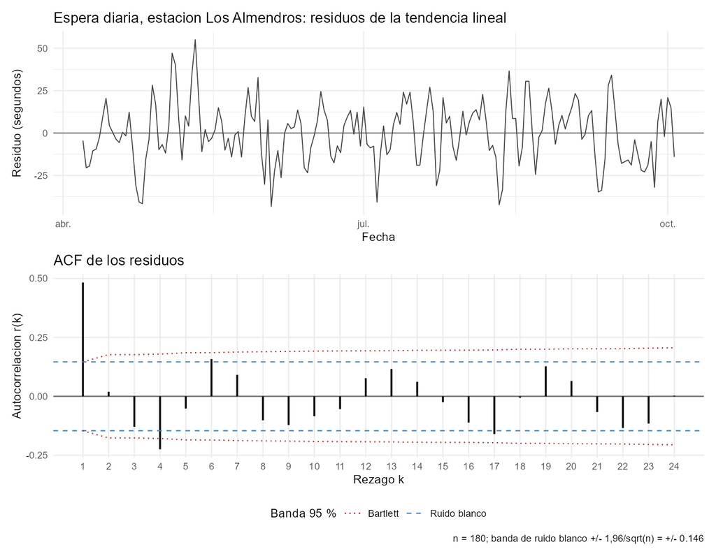

Residuos en el tiempo y su correlograma, tendencia lineal.

Rezagos de la ACF de los residuos fuera de la banda $\pm 1{,}96/\sqrt{n}$: 1, 4, 6, 17.

**Ljung–Box sobre los residuos.**

| Elemento | Contenido |
| --- | --- |
| 1. Hipotesis | H0: rho(1) = … = rho(14) = 0; H1: rho(k) != 0 para algun k en 1, …, 14 |
| 2. Estadistico y distribucion | Q = n(n+2) sum_{k=1}^{m} r_k^2/(n-k) ~ chi-cuadrado con 14 g.l. bajo H0 |
| 3. Region de rechazo (5 %) | Q > 23.685 |
| 4. Observado y valor p | observado = 73.3066; valor p = 4.831e-10 |
| 5. Decision | Se rechaza H0 al 5 % |
| 6. Lectura | Hay autocorrelacion conjunta significativa en los primeros 14 rezagos de los residuos de la tendencia lineal. |

**Jarque–Bera sobre los residuos.**

| Elemento | Contenido |
| --- | --- |
| 1. Hipotesis | H0: asimetria = 0 y curtosis = 3 (normalidad); H1: asimetria != 0 o curtosis != 3 |
| 2. Estadistico y distribucion | JB = n/6 [A^2 + (K - 3)^2/4] ~ chi-cuadrado con 2 g.l. (asintotica) bajo H0 |
| 3. Region de rechazo (5 %) | JB > 5.991 |
| 4. Observado y valor p | observado = 0.1624; valor p = 0.922 |
| 5. Decision | No se rechaza H0 al 5 % |
| 6. Lectura | No se rechaza normalidad de los errores. |

**Durbin–Watson (diagnóstico).** $d=1,031$, con $r_1=0,483$ y $2(1-r_1)=1,034$.

**Lectura.** La recta es el contraste de la serie 1 y la regresión confirma por qué: la pendiente, $0,015$ s por día, no se distingue de cero con el error robusto ($t=0,42$). El error HAC es 1,38 veces el ordinario porque los residuos tienen autocorrelación positiva: con $r_1=0,48$, cada día aporta menos información independiente de la que supone el error ordinario. Los residuos no son ruido blanco (Ljung–Box $Q=73,3$, $p<0{,}0001$) y $d=1,03$, lejos de 2, dice lo mismo. Esa es la dependencia de corto plazo que encontró la sección 5, y es la estructura que una tendencia determinista no aprovecha y que sí aprovechan la media móvil y el SES. La normalidad no se rechaza ($JB=0,16$).

**Serie 2: pasajeros del aeropuerto**

**Código**

```r
bloque_6b("serie2", "tend_ficticias")
```